# statsmodels

```python
import pandas as pd
import numpy as np
import statsmodels.api as sm
import statsmodels.tsa.api as tsa
import statsmodels.formula.api as smf
import matplotlib.pyplot as plt
import statsmodels
from statsmodels.graphics.tsaplots import plot_acf, plot_pacf
from statsmodels.graphics.api import qqplot
from scipy import stats
```

```python
import warnings
warnings.filterwarnings("ignore")
from IPython.core.interactiveshell import InteractiveShell
InteractiveShell.ast_node_interactivity = 'all'
```

```python
# 导入数据
data=pd.read_excel('./习题与案例数据/案例数据/A1_7.xlsx',index_col='year')
data.index=pd.date_range('1900','1999',freq='a')
data
```

|  | number |
| --- | --- |
| 1900-12-31 | 13 |
| 1901-12-31 | 14 |
| 1902-12-31 | 8 |
| 1903-12-31 | 10 |
| 1904-12-31 | 16 |
| ... | ... |
| 1994-12-31 | 15 |
| 1995-12-31 | 25 |
| 1996-12-31 | 22 |
| 1997-12-31 | 20 |
| 1998-12-31 | 16 |

99 rows × 1 columns

# 绘制时序图

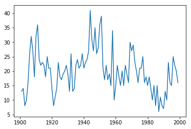

```python
plt.plot(data)
```

# 模型识别

## 序列的平稳性检验结果

```python
tsa.adfuller(data['number'])#array_like, 1d data series

help(tsa.adfuller)
```

```
(-3.183192251191782,
 0.02097842525600371,
 2,
 96,
 {'1%': -3.5003788874873405,
  '5%': -2.8921519665075235,
  '10%': -2.5830997960069446},
 549.0681467660734)
```

[output not shown]

[output cut: 28 more lines]

[output not shown]

```
maxlag：最大滞后阶数，也就是自回归阶数
regression：自回归项是一定被包括的，maxlag设定了阶数
'c':只有常数项（漂移项）
'ct':漂移项和趋势项
'nc':只有自回归项
'ctt':constant, and linear and quadratic trend
autolag：自动选择lag，基于bic，aic等准则，只有设置为None，自己设置的maxlag才会被使用，否则模型会自动选择最好的lag
其他的见上面
返回adf,p值，回归阶数，样本数，0.01,0.05,0.1分位点的值，aic等信息准则的值，等。
```

```python
tsa.adfuller(data.number,autolag=None,maxlag=1)#自己设置模型的lag为1
```

```
(-3.9178563779331284,
 0.001907294129421782,
 1,
 97,
 {'1%': -3.4996365338407074,
  '5%': -2.8918307730370025,
  '10%': -2.5829283377617176})
```

```python
reg=['nc','c','ct']
lag=[0,1,2]
model=['自回归','漂移项+自回归','漂移项+趋势项+自回归']
results=[]
for i in reg:
    for j in lag:
        types=model[reg.index(i)]
        stat,p=tsa.adfuller(data.number,autolag=None,maxlag=j,regression=i)[:2]
        results.append([types,j,stat,p])
pd.DataFrame(results,columns=['type','lag','统计量值','p值'])
```

|  | type | lag | 统计量值 | p值 |
| --- | --- | --- | --- | --- |
| 0 | 自回归 | 0 | -1.584539 | 0.106501 |
| 1 | 自回归 | 1 | -1.045064 | 0.266416 |
| 2 | 自回归 | 2 | -0.652610 | 0.432560 |
| 3 | 漂移项+自回归 | 0 | -5.353999 | 0.000004 |
| 4 | 漂移项+自回归 | 1 | -3.917856 | 0.001907 |
| 5 | 漂移项+自回归 | 2 | -3.183192 | 0.020978 |
| 6 | 漂移项+趋势项+自回归 | 0 | -5.551394 | 0.000018 |
| 7 | 漂移项+趋势项+自回归 | 1 | -4.141835 | 0.005471 |
| 8 | 漂移项+趋势项+自回归 | 2 | -3.509947 | 0.038338 |

```python
dir(tsa.adfuller(data.number,regresults=True)[-1])
tsa.adfuller(data.number,regresults=True)[-1].adfstat
```

```
['H0',
 'HA',
 '__class__',
 '__delattr__',
 '__dict__',
 '__dir__',
 '__doc__',
 '__eq__',
 '__format__',
 '__ge__',
 '__getattribute__',
 '__gt__',
 '__hash__',
 '__init__',
 '__init_subclass__',
 '__le__',
 '__lt__',
 '__module__',
 '__ne__',
 '__new__',
 '__reduce__',
 '__reduce_ex__',
 '__repr__',
 '__setattr__',
 '__sizeof__',
 '__str__',
 '__subclasshook__',
 '__weakref__',
 '_str',
 'adfstat',
 'autolag_results',
 'critvalues',
 'icbest',
 'maxlag',
 'nobs',
 'resols',
 'usedlag']
```

```
-3.183192251191782
```

从漂移项加自回归，或者漂移项+趋势项+自回归都可以看出，模型是平稳的

## 序列的纯随机性检验结果

纯随机性检验也就是LB检验，利用Q统计量

因为LB统计量（Q统计量的修正）是利用k阶延迟自相关系数来计算的，所以必须获得前k阶的自相关系数。k一般取6或12

```python
# 计算k阶延迟自相关
tsa.acf(data.number,nlags=12)#从0步到12步,但是实际计算q统计量是从1步开始算的。所以实际计算时应该去掉0步
```

```
array([ 1.        ,  0.54173285,  0.41888438,  0.39795532,  0.32404731,
        0.23716419,  0.17179424,  0.19022816,  0.06120181, -0.04850548,
       -0.10673042, -0.04327143, -0.07230482])
```

```python
#计算k阶延迟偏自相关
tsa.pacf(data.number,nlags=12)
```

```
array([ 1.        ,  0.54726074,  0.18276348,  0.17599425,  0.04046234,
       -0.02925253, -0.04206131,  0.0784646 , -0.14778847, -0.15651177,
       -0.1296911 ,  0.113972  ,  0.01187113])
```

```python
#计算Q统计量

q_acf=tsa.q_stat(tsa.acf(data.number,nlags=12)[1:],nobs=len(data.number))#用自相关系数计算Q统计量,nobs为总的样本量，而不是自相关的延迟阶数
#q_pacf=tsa.q_stat(tsa.pacf(data.number,nlags=12)[1:],nobs=len(data.number))
q_acf
#q_pacf
```

```
(array([29.94338136, 48.03065781, 64.52572016, 75.57794735, 81.56105668,
        84.73420816, 88.66715745, 89.07872742, 89.34012141, 90.61992405,
        90.83267742, 91.43353531]),
 array([4.44847764e-08, 3.71770714e-11, 6.33585229e-14, 1.50371504e-15,
        3.95511245e-16, 3.74733217e-16, 2.32297279e-16, 7.15231635e-16,
        2.20818568e-15, 4.03523693e-15, 1.14482818e-14, 2.60445654e-14]))
```

```python
help(tsa.q_stat)
```

```
Help on function q_stat in module statsmodels.tsa.stattools:

q_stat(x, nobs, type='ljungbox')
    Return's Ljung-Box Q Statistic

    x : array-like
        Array of autocorrelation coefficients.  Can be obtained from acf.
    nobs : int
        Number of observations in the entire sample (ie., not just the length
        of the autocorrelation function results.

    Returns
    -------
    q-stat : array
        Ljung-Box Q-statistic for autocorrelation parameters
    p-value : array
        P-value of the Q statistic

    Notes
    -----
    Written to be used with acf.
```

```python
def suiji(data,nobs,lag=12):
    suiji=pd.DataFrame()
    suiji['acf']=tsa.acf(data,nlags=lag)[1:]
    suiji['pacf']=tsa.pacf(data,nlags=lag)[1:]
    suiji['Q']=tsa.q_stat(tsa.acf(data,nlags=lag)[1:],nobs=nobs)[0]
    suiji['P']=tsa.q_stat(tsa.acf(data,nlags=lag)[1:],nobs=nobs)[1]
    return suiji
```

```python
suiji(data.number,lag=12,nobs=len(data.number))
```

|  | acf | pacf | Q | P |
| --- | --- | --- | --- | --- |
| 0 | 0.541733 | 0.547261 | 29.943381 | 4.448478e-08 |
| 1 | 0.418884 | 0.182763 | 48.030658 | 3.717707e-11 |
| 2 | 0.397955 | 0.175994 | 64.525720 | 6.335852e-14 |
| 3 | 0.324047 | 0.040462 | 75.577947 | 1.503715e-15 |
| 4 | 0.237164 | -0.029253 | 81.561057 | 3.955112e-16 |
| 5 | 0.171794 | -0.042061 | 84.734208 | 3.747332e-16 |
| 6 | 0.190228 | 0.078465 | 88.667157 | 2.322973e-16 |
| 7 | 0.061202 | -0.147788 | 89.078727 | 7.152316e-16 |
| 8 | -0.048505 | -0.156512 | 89.340121 | 2.208186e-15 |
| 9 | -0.106730 | -0.129691 | 90.619924 | 4.035237e-15 |
| 10 | -0.043271 | 0.113972 | 90.832677 | 1.144828e-14 |
| 11 | -0.072305 | 0.011871 | 91.433535 | 2.604457e-14 |

## 序列的各种自相关图

绘制时间序列图形的包在statsmodels中 `from statsmodels.graphics.tsaplots import plot_acf, plot_pacf`

```python
from statsmodels.graphics.tsaplots import plot_acf, plot_pacf
```

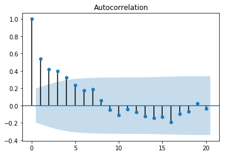

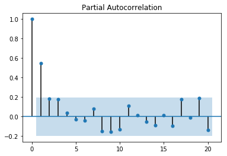

```python
plot_acf(data.number).show()
plot_pacf(data.number).show()
```

从相关图形和q统计量都可以看出，在短期内是存在相关性的，所以这是一个非纯随机时间序列，非白噪声序列。可以进行进一步的分析，也就是建模分析，预测。

# 模型构建

从自相关图可以看出是拖尾的，从偏相关图可以看出是截尾的。阶数为2.所以应该应用AR(2)模型

```python
#导入ar和arma模型的一种方式
from statsmodels.tsa import ar_model
from statsmodels.tsa import arima_model
ar_model.AR
arima_model.ARMA
```

```
statsmodels.tsa.ar_model.AR
```

```
statsmodels.tsa.arima_model.ARMA
```

```python
#导入statsmodels.api后，在tsa下可以直接运用模型
sm.tsa.AR
sm.tsa.ARMA
```

```
statsmodels.tsa.ar_model.AR
```

```
statsmodels.tsa.arima_model.ARMA
```

```python
help(sm.tsa.ARMA)
```

[output not shown]

[output cut: 174 more lines]

[output not shown]

我们下面只看ARMA的实现，因为AR模型就相当于与ARMA（p，0）

## 模型定阶

```python
#构建arma模型，首先是创建arma模型实例，给与一个时间序列数据
arma_mod20=sm.tsa.ARMA(data,(2,0))#数据是序列或数据框，索引是时间序列数据,并且设置阶数
arma_mod20fit=arma_mod20.fit(disp=-1,trend='c')#这里面可以选择方法和是否添加常数项等。默认有常数项
arma_mod20fit.summary()
```

ARMA Model Results

| Dep. Variable: | number | No. Observations: | 99 |
| --- | --- | --- | --- |
| Model: | ARMA(2, 0) | Log Likelihood | -317.367 |
| Method: | css-mle | S.D. of innovations | 5.958 |
| Date: | Sat, 10 Apr 2021 | AIC | 642.734 |
| Time: | 21:21:47 | BIC | 653.114 |
| Sample: | 12-31-1900 | HQIC | 646.934 |
|  | - 12-31-1998 |  |  |

|  | coef | std err | z | P>\|z\| | [0.025 | 0.975] |
| --- | --- | --- | --- | --- | --- | --- |
| const | 19.8146 | 1.563 | 12.674 | 0.000 | 16.750 | 22.879 |
| ar.L1.number | 0.4457 | 0.098 | 4.528 | 0.000 | 0.253 | 0.639 |
| ar.L2.number | 0.1788 | 0.099 | 1.815 | 0.073 | -0.014 | 0.372 |

Roots

|  | Real | Imaginary | Modulus | Frequency |
| --- | --- | --- | --- | --- |
| AR.1 | 1.4269 | +0.0000j | 1.4269 | 0.0000 |
| AR.2 | -3.9192 | +0.0000j | 3.9192 | 0.5000 |

其实python中还允许利用函数来判断一个arma模型的平稳性和可逆性，`from statsmodels.tsa.arima_process import ArmaProcess`

但是需要事先构建模型获得系数参数

```python
from statsmodels.tsa.arima_process import ArmaProcess
np.random.seed(1234)
# include zero-th lag
#arma（4,1）
arparams = np.array([1, .75, -.65, -.55, .9])#4阶ar，注意需要包含0阶，这实际上就是自回归系数多项式
maparams = np.array([1, .65])#1阶ma，注意需要包含0阶，这实际上就是系数多项式
arma_t = ArmaProcess(arparams, maparams)#传递ar和ma的系数参数
arma_t.isinvertible#判断可逆性
arma_t.isstationary#判断平稳性
```

```
True
```

```
False
```

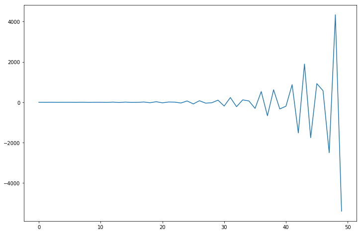

```python
fig = plt.figure(figsize=(12,8))
ax = fig.add_subplot(111)
ax.plot(arma_t.generate_sample(nsample=50));
```

见模型定阶的简便方法

另外需要注意的是python中的arma模型不允许构建不平稳的模型，否则会报错。所以我们先在利用bic准则，查看5阶内所有的模型的bic量，对于报错的我们把它的bic定为无穷

```python
p=range(6)
q=range(6)
rank=[]
for i in p:
    con=[]
    for j in q:
        try:
            con.append(arima_model.ARMA(data.number,(i,j)).fit(disp=-1).bic)
        except:
            con.append(np.Inf)
    rank.append(con)
rank=pd.DataFrame(rank,index=['AR'+str(i) for i in p],columns=['MA'+str(j) for j in q])
rank
```

|  | MA0 | MA1 | MA2 | MA3 | MA4 | MA5 |
| --- | --- | --- | --- | --- | --- | --- |
| AR0 | 681.734599 | 662.632218 | 662.113706 | 660.906160 | 662.699747 | 666.007394 |
| AR1 | 651.753037 | 650.836763 | 655.356467 | 658.633388 | 662.940464 | 667.036829 |
| AR2 | 653.114333 | inf | 658.039309 | inf | inf | inf |
| AR3 | 654.472268 | 658.915996 | 663.356277 | 665.307412 | inf | inf |
| AR4 | 658.853051 | 663.431867 | 665.500353 | 670.043316 | inf | inf |
| AR5 | 663.385982 | 665.232821 | 672.597914 | 679.265916 | 671.782722 | inf |

```python
rank.min()
```

```
MA0    651.753037
MA1    650.836763
MA2    655.356467
MA3    658.633388
MA4    662.699747
MA5    666.007394
dtype: float64
```

可以看到AR(1,1)模型bic最小，并且模型平稳，我们最终模型定阶为（1，1）

## model的一些方法和参数

```python
arma_mod11=sm.tsa.ARMA(data,(1,1))
arma_mod11fit=arma_mod11.fit(disp=-1)
arma_mod11fit.summary()
```

ARMA Model Results

| Dep. Variable: | number | No. Observations: | 99 |
| --- | --- | --- | --- |
| Model: | ARMA(1, 1) | Log Likelihood | -316.228 |
| Method: | css-mle | S.D. of innovations | 5.888 |
| Date: | Sat, 10 Apr 2021 | AIC | 640.456 |
| Time: | 21:21:54 | BIC | 650.837 |
| Sample: | 12-31-1900 | HQIC | 644.656 |
|  | - 12-31-1998 |  |  |

|  | coef | std err | z | P>\|z\| | [0.025 | 0.975] |
| --- | --- | --- | --- | --- | --- | --- |
| const | 19.6684 | 1.900 | 10.352 | 0.000 | 15.945 | 23.392 |
| ar.L1.number | 0.8306 | 0.086 | 9.612 | 0.000 | 0.661 | 1.000 |
| ma.L1.number | -0.4369 | 0.137 | -3.190 | 0.002 | -0.705 | -0.168 |

Roots

|  | Real | Imaginary | Modulus | Frequency |
| --- | --- | --- | --- | --- |
| AR.1 | 1.2039 | +0.0000j | 1.2039 | 0.0000 |
| MA.1 | 2.2889 | +0.0000j | 2.2889 | 0.0000 |

```python
arma_mod11fit.params
arma_mod11fit.arparams
arma_mod11fit.maparams
arma_mod11fit.model
arma_mod11fit.arroots
arma_mod11fit.aic
arma_mod11fit.bic
arma_mod11fit.nobs#样本数
arma_mod11fit.pvalues#ar和ma系数的检验p值
#arma_mod11fit.predict() 会在预测时讲到
#arma_mod11fit.plot_predict()
arma_mod11fit.resid#模型误差，可以用来检验模型的显著性，以及事先关于残差的假定
#arma_mod11fit.normalized_cov_params()有问题
```

```
const           19.668380
ar.L1.number     0.830628
ma.L1.number    -0.436884
dtype: float64
```

```
array([0.83062787])
```

```
array([-0.43688365])
```

```
<statsmodels.tsa.arima_model.ARMA at 0x168dc334d08>
```

```
array([1.20390856])
```

```
640.4562835731904
```

```
650.8367629737287
```

```
99
```

```
const           2.611218e-17
ar.L1.number    1.015489e-15
ma.L1.number    1.924677e-03
dtype: float64
```

```
1900-12-31   -6.668380
1901-12-31   -2.071618
1902-12-31   -7.810983
1903-12-31   -3.350267
1904-12-31    2.901916
                ...
1994-12-31   -2.550478
1995-12-31    8.095044
1996-12-31    1.439620
1997-12-31   -0.976142
1998-12-31   -4.370293
Freq: A-DEC, Length: 99, dtype: float64
```

## 假设的检验

包括模型的显著性，也即残差是否是一个白噪声序列

残差的相关性检验，DW检验

对于arma模型，我们假定残差服从正态分布，所以需要检验残差的正态性

### 残差的相关性检验

```python
sm.stats.durbin_watson(arma_mod11fit.resid.values)
```

```
1.959664111340092
```

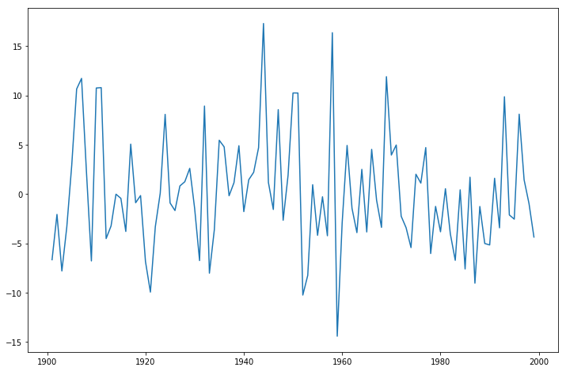

```python
fig = plt.figure(figsize=(12,8))
ax1 = fig.add_subplot(111)
ax1.plot(arma_mod11fit.resid)
```

### 残差的正态性检验

```
NormaltestResult(statistic=5.939742977265384, pvalue=0.051309903814136935)
```

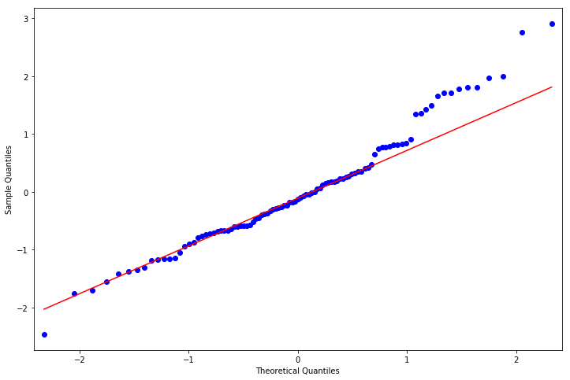

```python
from scipy import stats
#正态检验
resid = arma_mod11fit.resid
stats.normaltest(resid)#利用stats包中的正态测试
#利用qq图
from statsmodels.graphics.api import qqplot
fig = plt.figure(figsize=(12,8))
ax = fig.add_subplot(111)
fig = qqplot(resid, line='q', ax=ax, fit=True)
```

### 残差的随机性检验

即检验模型的显著性

```
            AC          Q  Prob(>Q)
lag
1.0   0.010300   0.010825  0.917133
2.0  -0.063396   0.425117  0.808513
3.0   0.065777   0.875755  0.831274
4.0   0.047298   1.111215  0.892489
5.0  -0.004223   1.113112  0.952937
6.0  -0.028136   1.198227  0.976972
7.0   0.144325   3.462101  0.839223
8.0  -0.002454   3.462763  0.902060
9.0  -0.113296   4.888849  0.843888
10.0 -0.157036   7.659406  0.662066
11.0  0.045036   7.889868  0.723134
12.0  0.018466   7.929059  0.790649
13.0 -0.056399   8.298885  0.823598
14.0 -0.067152   8.829343  0.841825
15.0 -0.011891   8.846175  0.885422
16.0 -0.171222  12.377992  0.717576
17.0 -0.011226  12.393360  0.775755
18.0 -0.019499  12.440294  0.823693
19.0  0.147969  15.176856  0.711292
20.0 -0.014903  15.204967  0.764562
21.0 -0.023304  15.274586  0.808926
22.0  0.098692  16.539408  0.788244
23.0 -0.148043  19.422915  0.676424
24.0 -0.092072  20.553106  0.664927
25.0  0.050855  20.902567  0.698030
26.0  0.171934  24.951672  0.521712
27.0 -0.003867  24.953749  0.577054
28.0  0.003667  24.955643  0.630249
29.0 -0.088285  26.068993  0.621801
30.0  0.042425  26.329814  0.658196
31.0 -0.039924  26.564193  0.693876
32.0  0.075991  27.425989  0.697433
33.0  0.091602  28.697210  0.681352
34.0  0.053442  29.136551  0.704902
35.0 -0.034872  29.326542  0.738179
36.0 -0.068495  30.071156  0.745837
37.0  0.060894  30.669183  0.759259
38.0 -0.057669  31.214327  0.774112
39.0  0.030721  31.371606  0.802514
40.0  0.020507  31.442874  0.831202
```

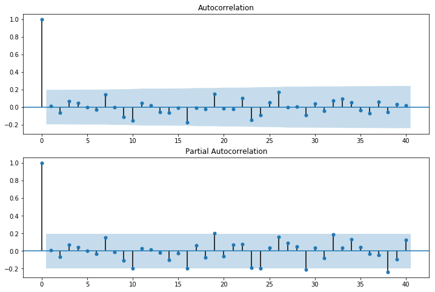

```python
#残差的随机性检验
r,q,p = sm.tsa.acf(resid.values.squeeze(), fft=True, qstat=True)
data1 = np.c_[range(1,41), r[1:], q, p]#默认是40期
table = pd.DataFrame(data1, columns=['lag', "AC", "Q", "Prob(>Q)"])
print(table.set_index('lag'))
#当残差的随机性检验不通过的时候，可以通过残差的相关图看看还有哪些相关关系未提取干净
fig = plt.figure(figsize=(12,8))
ax1 = fig.add_subplot(211)
fig = sm.graphics.tsa.plot_acf(resid.values.squeeze(), lags=40, ax=ax1)
ax2 = fig.add_subplot(212)
fig = sm.graphics.tsa.plot_pacf(resid, lags=40, ax=ax2)
```

从检验看出残差之间相关性很弱，满足假设

## 预测

利用模型的predict函数和predict_plot函数，可以预测值，以及绘制预测值的图

```python
arma_mod11fit.predict('1980','2005')
```

```
1980-12-31    17.465377
1981-12-31    18.049009
1982-12-31    16.729012
1983-12-31    14.577349
1984-12-31    15.606044
1985-12-31    13.299255
1986-12-31    15.047666
1987-12-31    12.267820
1988-12-31    13.022072
1989-12-31    12.170360
1990-12-31    11.404516
1991-12-31    13.432397
1992-12-31    13.137112
1993-12-31    18.126782
1994-12-31    17.550478
1995-12-31    16.904956
1996-12-31    20.560380
1997-12-31    20.976142
1998-12-31    20.370293
1999-12-31    18.530631
2000-12-31    18.723334
2001-12-31    18.883399
2002-12-31    19.016353
2003-12-31    19.126788
2004-12-31    19.218519
2005-12-31    19.294713
Freq: A-DEC, dtype: float64
```

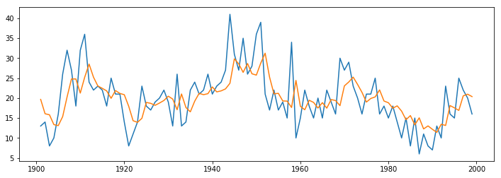

```python
fig, ax = plt.subplots(figsize=(12, 4))
ax.plot(data)
#arma_mod11fit.plot_predict('2000', '2006',)有问题
ax.plot(arma_mod11fit.predict())
```

```python
arma_mod11fit.fittedvalues
```

```
1900-12-31    19.668380
1901-12-31    16.071618
1902-12-31    15.810983
1903-12-31    13.350267
1904-12-31    13.098084
                ...
1994-12-31    17.550478
1995-12-31    16.904956
1996-12-31    20.560380
1997-12-31    20.976142
1998-12-31    20.370293
Freq: A-DEC, Length: 99, dtype: float64
```

```python
arma_mod11fit.forecast(5)
```

```
(array([18.5306311 , 18.72333411, 18.8833986 , 19.01635263, 19.12678795]),
 array([5.88763837, 6.32759403, 6.61409924, 6.80474257, 6.93322013]),
 array([[ 6.99107194, 30.07019026],
        [ 6.32147771, 31.12519051],
        [ 5.92000229, 31.84679491],
        [ 5.67930228, 32.35340298],
        [ 5.5379262 , 32.7156497 ]]))
```

```python
arma_mod11fit.predict('1999','2005')
```

```
1999-12-31    18.530631
2000-12-31    18.723334
2001-12-31    18.883399
2002-12-31    19.016353
2003-12-31    19.126788
2004-12-31    19.218519
2005-12-31    19.294713
Freq: A-DEC, dtype: float64
```

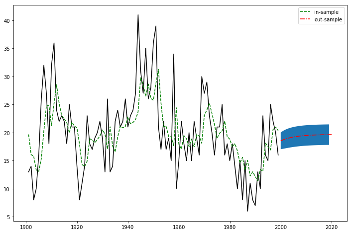

```python
fig,ax=plt.subplots(figsize=(12,8))
ax.plot(data,color='black')
ax.plot(arma_mod11fit.predict(),ls='--',color='green',label='in-sample')
ax.plot(arma_mod11fit.predict('1999','2019'),ls='-.',color='red',label='out-sample')
l,r=arma_mod11fit.forecast(20,alpha=0.8)[2][:,0],arma_mod11fit.forecast(20,alpha=0.8)[2][:,1]
ax.fill_between(pd.date_range('1999','2019',freq='a'),l,r)
ax.legend()
```

```python
help(arma_mod11fit.forecast)
```

```
Help on method forecast in module statsmodels.tsa.arima_model:

forecast(steps=1, exog=None, alpha=0.05) method of statsmodels.tsa.arima_model.ARMAResults instance
    Out-of-sample forecasts

    Parameters
    ----------
    steps : int
        The number of out of sample forecasts from the end of the
        sample.
    exog : array
        If the model is an ARMAX, you must provide out of sample
        values for the exogenous variables. This should not include
        the constant.
    alpha : float
        The confidence intervals for the forecasts are (1 - alpha) %

    Returns
    -------
    forecast : array
        Array of out of sample forecasts
    stderr : array
        Array of the standard error of the forecasts.
    conf_int : array
        2d array of the confidence interval for the forecast
```

```python
help(arma_mod11fit.predict)
```

[output not shown]

## 生成相应系数的arma模型以及样本

```python
## 利用from statsmodels.tsa.arima_process import ArmaProcess

arpar=np.r_[1,-arma_mod11fit.arparams]#注意负号
maapr=np.r_[1,arma_mod11fit.maparams]
arma_t=ArmaProcess(arpar,maapr)
arma_t.generate_sample(50)#生成样本数
```

```
array([ 0.84100879, -1.11466772, -1.69619658, -0.89732715, -1.24949787,
       -0.9429691 , -0.36605419, -0.49423353,  0.17072922,  1.44030944,
       -0.45314823, -0.0211145 ,  0.32116309, -0.07627831,  1.06153154,
       -1.97036659,  1.44268116, -0.83143763,  0.02046505,  0.62915108,
       -0.57072571,  0.33114286,  0.77741837,  0.86158753, -0.43930777,
        2.04760704,  1.05056826, -0.37918406,  0.82059652,  0.44502154,
        0.81677717, -3.08796419,  0.31299866, -0.16455348, -0.03883496,
       -0.53423336,  0.5115214 ,  1.07455292,  0.73309407,  1.88259081,
        1.0354387 ,  0.42521786, -0.49991477, -0.55091025,  0.61444634,
        0.07167267, -0.24943137,  0.47172613, -0.90796036, -0.79903477])
```

```python
dir(arma_t)
```

```
['__class__',
 '__delattr__',
 '__dict__',
 '__dir__',
 '__doc__',
 '__eq__',
 '__format__',
 '__ge__',
 '__getattribute__',
 '__gt__',
 '__hash__',
 '__init__',
 '__init_subclass__',
 '__le__',
 '__lt__',
 '__module__',
 '__mul__',
 '__ne__',
 '__new__',
 '__reduce__',
 '__reduce_ex__',
 '__repr__',
 '__setattr__',
 '__sizeof__',
 '__str__',
 '__subclasshook__',
 '__weakref__',
 'acf',
 'acovf',
 'ar',
 'arcoefs',
 'arma2ar',
 'arma2ma',
 'arpoly',
 'arroots',
 'from_coeffs',
 'from_estimation',
 'generate_sample',
 'impulse_response',
 'invertroots',
 'isinvertible',
 'isstationary',
 'ma',
 'macoefs',
 'mapoly',
 'maroots',
 'nobs',
 'pacf',
 'periodogram']
```

生成相应模型后，可以计算模型的自相关，偏自相关，自协方差函数等

```python
arma_t.acf(12)
arma_t.pacf(12)
arma_t.acovf(12)
```

```
array([1.        , 0.53937576, 0.44802054, 0.37213835, 0.30910848,
       0.25675412, 0.21326713, 0.17714562, 0.14714209, 0.12222032,
       0.1015196 , 0.08432501])
```

```
array([1.00000000e+00, 5.39375760e-01, 2.21548631e-01, 9.56983544e-02,
       4.17191583e-02, 1.82189418e-02, 7.95893463e-03, 3.47707644e-03,
       1.51907351e-03, 6.63658016e-04, 2.89941305e-04, 1.26670613e-04])
```

```
array([1.50001883, 0.8090738 , 0.67203925, 0.55821453, 0.46366854,
       0.38513601, 0.31990471, 0.26572176, 0.2207159 , 0.18333278,
       0.15228132, 0.12648911])
```

```python
## 利用arma_generate_sample()

sm.tsa.arma_generate_sample(arpar,maapr,50)
```

```
array([ 0.29120536,  0.68119412,  0.82190127,  0.74797878,  0.98093912,
        1.96669932,  0.25680721,  0.08654568,  1.50093088, -0.56938977,
        0.96221975, -1.29394972, -0.77817225,  0.29972415, -0.28227105,
       -0.32754268,  0.48817939, -1.71037106, -0.57913776, -0.10676858,
       -0.509618  , -0.93247366, -1.18755667, -0.25181921, -2.10277464,
       -0.60889419, -1.15709421, -1.05072217, -0.0480205 ,  0.33550013,
        0.22174955,  0.23075989,  0.94173438,  2.31921265,  1.73878118,
        0.20280618, -1.49651451,  1.59821857, -1.25111724,  0.9293164 ,
        1.04055467,  0.13611643,  0.98155745, -0.34197525,  1.26426066,
        0.01166392,  0.93966998,  1.45848901,  0.65975754,  2.96696278])
```

```python
#验证一下确实是模型的自相关，偏自相关
# 生成一个平稳arma(1,0)模型
ar1=np.array([1,0.8])
ma1=np.array([1])
arma20=ArmaProcess(ar1,ma1)
arma20.acf(12)#ar（1）模型的k阶自相关应该是系数的k次方
arma20.pacf(12)#除了1阶为系数，其他皆为0
np.array([0.8**i for i in range(12)])
#验证是通过的
```

```
array([ 1.        , -0.8       ,  0.64      , -0.512     ,  0.4096    ,
       -0.32768   ,  0.262144  , -0.2097152 ,  0.16777216, -0.13421773,
        0.10737418, -0.08589935])
```

```
array([ 1.00000000e+00, -8.00000000e-01, -3.45402719e-16, -6.16790569e-17,
        4.31753398e-17, -3.25171988e-17, -1.04854397e-16,  7.70988212e-17,
        1.23358114e-17, -4.62592927e-17, -1.38777878e-17,  1.07938350e-17])
```

```
array([1.        , 0.8       , 0.64      , 0.512     , 0.4096    ,
       0.32768   , 0.262144  , 0.2097152 , 0.16777216, 0.13421773,
       0.10737418, 0.08589935])
```

## 模型定阶的简便方法

设置最大和最小AR、MA阶数，给与data和信息准则，信息准则可以是一个字符串或一个列表，同时可以选择是否中心化。检测后，可以利用.aic_min_order或.bic_min_order等你选择的最小准则选择最佳的模型，并且模型一定是平稳和可逆的。不满足的无值

```python
help(sm.tsa.arma_order_select_ic)
```

```
Help on function arma_order_select_ic in module statsmodels.tsa.stattools:

arma_order_select_ic(y, max_ar=4, max_ma=2, ic='bic', trend='c', model_kw=None, fit_kw=None)
    Returns information criteria for many ARMA models

    Parameters
    ----------
    y : array-like
        Time-series data
    max_ar : int
        Maximum number of AR lags to use. Default 4.
    max_ma : int
        Maximum number of MA lags to use. Default 2.
    ic : str, list
        Information criteria to report. Either a single string or a list
        of different criteria is possible.
    trend : str
        The trend to use when fitting the ARMA models.
    model_kw : dict
        Keyword arguments to be passed to the ``ARMA`` model
    fit_kw : dict
        Keyword arguments to be passed to ``ARMA.fit``.

    Returns
    -------
    obj : Results object
        Each ic is an attribute with a DataFrame for the results. The AR order
        used is the row index. The ma order used is the column index. The
        minimum orders are available as ``ic_min_order``.

    Examples
    --------

    >>> from statsmodels.tsa.arima_process import arma_generate_sample
    >>> import statsmodels.api as sm
    >>> import numpy as np

    >>> arparams = np.array([.75, -.25])
    >>> maparams = np.array([.65, .35])
    >>> arparams = np.r_[1, -arparams]
    >>> maparam = np.r_[1, maparams]
    >>> nobs = 250
    >>> np.random.seed(2014)
    >>> y = arma_generate_sample(arparams, maparams, nobs)
    >>> res = sm.tsa.arma_order_select_ic(y, ic=['aic', 'bic'], trend='nc')
    >>> res.aic_min_order
    >>> res.bic_min_order

    Notes
    -----
    This method can be used to tentatively identify the order of an ARMA
    process, provided that the time series is stationary and invertible. This
    function computes the full exact MLE estimate of each model and can be,
    therefore a little slow. An implementation using approximate estimates
    will be provided in the future. In the meantime, consider passing
    {method : 'css'} to fit_kw.
```

```python
mod_ch=sm.tsa.arma_order_select_ic(data,4,4,['aic','bic'],trend='nc')
mod_ch
```

```
{'aic':             0           1           2           3           4
 0         NaN  799.674173  761.067479  738.361676  715.759799
 1  666.645525  647.132300  648.738566  649.986452  651.941850
 2  656.028374  648.842840  648.850644  650.846599  652.699837
 3  649.748166  650.009945  652.004944         NaN  654.552222
 4  650.228277  652.004611         NaN  651.799867  654.256041,
 'bic':             0           1           2           3           4
 0         NaN  804.864412  768.852838  748.742155  728.735398
 1  671.835765  654.917660  659.119046  662.962051  667.512569
 2  663.813734  659.223319  661.826244  666.417318  670.865676
 3  660.128646  662.985544  667.575663         NaN  675.313181
 4  663.203877  667.575330         NaN  672.560826  677.612119,
 'aic_min_order': (1, 1),
 'bic_min_order': (1, 1)}
```

```python
dir(mod_ch)
```

```
['__class__',
 '__contains__',
 '__delattr__',
 '__delitem__',
 '__dict__',
 '__dir__',
 '__doc__',
 '__eq__',
 '__format__',
 '__ge__',
 '__getattribute__',
 '__getitem__',
 '__gt__',
 '__hash__',
 '__init__',
 '__init_subclass__',
 '__iter__',
 '__le__',
 '__len__',
 '__lt__',
 '__module__',
 '__ne__',
 '__new__',
 '__reduce__',
 '__reduce_ex__',
 '__repr__',
 '__setattr__',
 '__setitem__',
 '__sizeof__',
 '__str__',
 '__subclasshook__',
 '__weakref__',
 'aic',
 'aic_min_order',
 'bic',
 'bic_min_order',
 'clear',
 'copy',
 'fromkeys',
 'get',
 'items',
 'keys',
 'pop',
 'popitem',
 'setdefault',
 'update',
 'values']
```

```python
mod_ch.keys()
```

```
dict_keys(['aic', 'bic', 'aic_min_order', 'bic_min_order'])
```

## 模型总结

sm.tsa=tsa

| 步骤 | 方法 | 解释 |
| --- | --- | --- |
| 模型定阶 | `sm.tsa.arma_order_select_ic(data,max_ar,max_ma,ic,trend,model_kw,fit_kw)` | data:数据 max_ar,max_ma:最大的阶数 ic:字符串或者列表,指定信息准则 trend:'c'or‘nc’,是否中心化 model_kw,fit_kw:arma以及arma.fit的参数 |
| 模型构建 | 按照数据和阶数构建： `arma_mod=sm.tsa.ARMA(data)` `arma_modfit=arma_mod.fit(disp=-1,trend='c')` | arma_mod的参数一般只需要输入data，序列或数据框，索引为时间类型。 fit的时候可以选择计算方法，是否包含常数项等. 通过summary方法可以看到模型的信息量，参数的检验结果，系数，系数多项式的根。 还有其他属性可以获得参数值，ar或ma参数，ar或ma的根，信息量，残差等。 但是无法计算模型的协方差等信息 |
| - | 按照ar和ma的系数构建，注意即延迟算子形式的系数 `from sm.tsa.arima_process import ArmaProcess` `ArmaProcess(ar,ma)` | ar:ar的所有系数 ma:ma的所有系数 此模型也可以获得ar，ma等系数，根 同时还可以获取**模型的自协方差，自相关系数等** 同时还可以检验模型的可逆性和稳定性 同时还可以获得模型的逆转形式的系数多项式的根 |
| 生成相应模型样本（非必要步骤） | `sm.tsa.arma.generate_sample(ar,ma,nobs)`或 `AramaProcess(ar,ma).generate_sample(nsample)` | 可以直接调用函数，也可以通过先生成模型再进行生成样本 |
| 检验模型 | 模型的显著性检验:`r,q,p = sm.tsa.acf(resid, fft=True, qstat=True)`默认nlags40 残差的相关性检验：`sm.stats.durbin_watson(arma_mod11fit.resid.values)` 残差的正态性检验:`scipy.stats.normaltest(resid)` 模型的参数检验：在生成模型的时候就已经可以判断，如果有参数… | r,q,p代表自相关值，q统计量值，p值，判断残差随机性 dw检验也检验残差的相关性 正态检验还可以通过`statsmodels.graphics.api.qqplot(resid, line='q', ax=ax, fit=True)`判断拟合效果 |
| 模型预测 | `.predict(开始时间,结束时间)` | 注意不要设置dynamic=True，否则预测值会近似一条直线 可以将预测值和样本值放在一起比较结果 |

# 非平稳时间序列

cramer分解定理证明任何一个序列都可以视为同时受到确定性影响和随机性影响的作用，对于非平稳时间序列，这两方面至少有一个方面是不平稳的。

# ARIMA 非平稳无季节效应时间序列

当时间序列非平稳但是不存在其他诸如季节效应的随机影响时，一般只需要做差分就可以获得平稳序列。可能是一阶，二阶，并且可以证明d阶差分后一定是平稳的，但是差分阶数越高，方差越大，所以我们要选择合适的差分阶数。避免出现过差分现象

其实差分就是自回归，一个差分可以写成自回归的形式，就是用自回归来提取序列中蕴含的确定性信息

**对蕴含固定周期的序列进行步长为周期长度的差分运算，(k步差分)通常可以可以很好的提取周期信息**，这和有季节因素的非平稳序列比较有关系

ARIMA（p，d，q）p，q和ARMA模型一致，d代表做几阶差分。当p=q=0，d=0时，$x_t=x_{t-1}+\epsilon$,称为随机游走模型或醉汉模型

```
arima_mod=tsa.SARIMAX(data,order=(p,d,q))
arima_modpdq=arima_modpdq.fit(disp=-1)
```

```python
help(tsa.statespace.SARIMAX)
```

[output not shown]

[output cut: 802 more lines]

[output not shown]

## 导入数据，判断数据是否平稳

```python
import requests
from io import BytesIO
wpi1 = requests.get('https://www.stata-press.com/data/r12/wpi1.dta').content
data = pd.read_stata(BytesIO(wpi1))
data.index = data.t
```

```python
data
```

| t | wpi | t | ln_wpi |
| --- | --- | --- | --- |
| 1960-01-01 | 30.700001 | 1960-01-01 | 3.424263 |
| 1960-04-01 | 30.799999 | 1960-04-01 | 3.427515 |
| 1960-07-01 | 30.700001 | 1960-07-01 | 3.424263 |
| 1960-10-01 | 30.700001 | 1960-10-01 | 3.424263 |
| 1961-01-01 | 30.799999 | 1961-01-01 | 3.427515 |
| ... | ... | ... | ... |
| 1989-10-01 | 109.400002 | 1989-10-01 | 4.695011 |
| 1990-01-01 | 111.000000 | 1990-01-01 | 4.709530 |
| 1990-04-01 | 110.800003 | 1990-04-01 | 4.707727 |
| 1990-07-01 | 112.800003 | 1990-07-01 | 4.725616 |
| 1990-10-01 | 116.199997 | 1990-10-01 | 4.755313 |

124 rows × 3 columns

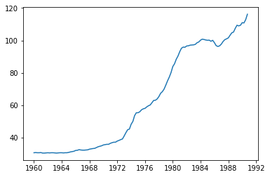

```python
plt.plot(data.wpi)
```

可以判断大致应该是做一阶差分

## 更加精确的判断，差分并做单位根检验

```python
def select_arima_orderd_adf(data,maxlag):
    results=[tsa.adfuller(data.diff(i).dropna())[1] for i in range(1,maxlag+1)]
    results=pd.DataFrame(results,index=range(1,maxlag+1),columns=['p值'])
    results._set_axis_name('差分阶数',inplace=True)
    return results
```

```python
select_arima_orderd_adf(data.wpi,5)
```

| 差分阶数 | p值 |
| --- | --- |
| 1 | 0.098945 |
| 2 | 0.121322 |
| 3 | 0.069117 |
| 4 | 0.359309 |
| 5 | 0.122730 |

这里其实全部都没有通过0.05的检验，那我们就取0.1为标准，所以一阶差分就可

## 构建ARIMA模型

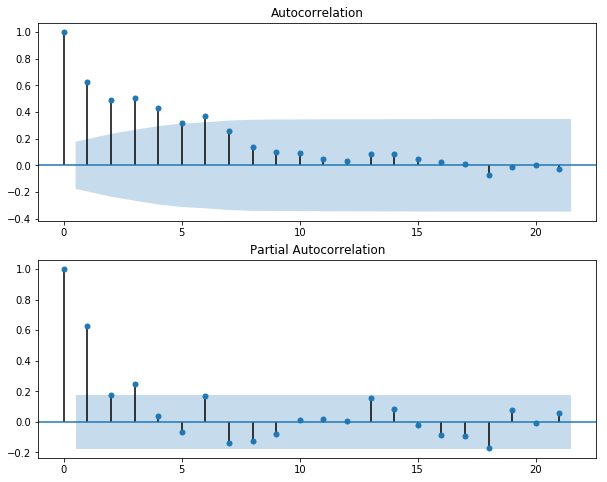

```python
#首先获取差分数据
data['d1wpi']=data['wpi'].diff()
#绘制相关图。判断p，q
fig=plt.figure(figsize=(10,8))
ax1=plt.subplot(211);plot_acf(data.d1wpi.dropna(),ax=ax1).show()
ax2=plt.subplot(212);plot_pacf(data.d1wpi.dropna(),ax=ax2).show()
```

根据自相关图和偏相关图，我们也可以判断是否适合用疏系数模型

```python
#使用模型定阶的函数
tsa.arma_order_select_ic(data.d1wpi.dropna(),4,4,['aic','bic'],trend='c')
```

```
{'aic':             0           1           2           3           4
 0  347.072562  307.552197  299.357225  293.948300  285.064261
 1  283.806987  278.702628  280.105905  280.726991  281.041604
 2  281.855956  280.368858  281.696667  279.304674  280.894012
 3  278.371786  280.281285         NaN  304.722568  279.878126
 4  280.205568  279.706951  279.272632  280.581639  281.139270,
 'bic':             0           1           2           3           4
 0  352.696930  315.988750  310.605962  308.009222  301.937367
 1  292.243540  289.951365  294.166827  297.600097  300.726894
 2  293.104694  294.429780  298.569774  298.989965  303.391487
 3  292.432708  297.154391         NaN  327.220043  305.187785
 4  297.078674  299.392241  301.770106  305.891298  309.261113,
 'aic_min_order': (3, 0),
 'bic_min_order': (1, 1)}
```

使用bic准则我们p=1，q=1

```python
#构建模型
arima_mod111=tsa.SARIMAX(data['wpi'],order=(1,1,1),trend='c')
arima_mod111fit=arima_mod111.fit(disp=-1)
arima_mod111fit.summary()
```

Statespace Model Results

| Dep. Variable: | wpi | No. Observations: | 124 |
| --- | --- | --- | --- |
| Model: | SARIMAX(1, 1, 1) | Log Likelihood | -135.351 |
| Date: | Sat, 10 Apr 2021 | AIC | 278.703 |
| Time: | 21:22:07 | BIC | 289.951 |
| Sample: | 01-01-1960 | HQIC | 283.272 |
|  | - 10-01-1990 |  |  |
| Covariance Type: | opg |  |  |

|  | coef | std err | z | P>\|z\| | [0.025 | 0.975] |
| --- | --- | --- | --- | --- | --- | --- |
| intercept | 0.0943 | 0.068 | 1.389 | 0.165 | -0.039 | 0.227 |
| ar.L1 | 0.8742 | 0.055 | 16.028 | 0.000 | 0.767 | 0.981 |
| ma.L1 | -0.4120 | 0.100 | -4.119 | 0.000 | -0.608 | -0.216 |
| sigma2 | 0.5257 | 0.053 | 9.849 | 0.000 | 0.421 | 0.630 |

| Ljung-Box (Q): | 37.12 | Jarque-Bera (JB): | 9.78 |
| --- | --- | --- | --- |
| Prob(Q): | 0.60 | Prob(JB): | 0.01 |
| Heteroskedasticity (H): | 15.93 | Skew: | 0.28 |
| Prob(H) (two-sided): | 0.00 | Kurtosis: | 4.26 |

Warnings:  
[1] Covariance matrix calculated using the outer product of gradients (complex-step).

## 预测

```python
arima_mod111fit.predict('1960-01-01','1991-01-01')
```

```
1960-01-01      0.749786
1960-04-01     31.449807
1960-07-01     31.122188
1960-10-01     30.867851
1961-01-01     30.862600
                 ...
1990-01-01    109.912121
1990-04-01    112.044809
1990-07-01    111.232380
1990-10-01    113.996828
1991-01-01    118.358861
Freq: QS-OCT, Length: 125, dtype: float64
```

```python
arima_mod111fit.get_prediction()
arima_mod111fit.get_prediction().conf_int()
```

```
<statsmodels.tsa.statespace.mlemodel.PredictionResultsWrapper at 0x168debe0c48>
```

|  | lower wpi | upper wpi |
| --- | --- | --- |
| 1960-01-01 | -1959.215181 | 1960.714753 |
| 1960-04-01 | 29.487836 | 33.411777 |
| 1960-07-01 | 29.644898 | 32.599478 |
| 1960-10-01 | 29.437815 | 32.297886 |
| 1961-01-01 | 29.440036 | 32.285163 |
| ... | ... | ... |
| 1989-10-01 | 108.144279 | 110.986387 |
| 1990-01-01 | 108.491066 | 111.333175 |
| 1990-04-01 | 110.623755 | 113.465863 |
| 1990-07-01 | 109.811325 | 112.653434 |
| 1990-10-01 | 112.575774 | 115.417882 |

124 rows × 2 columns

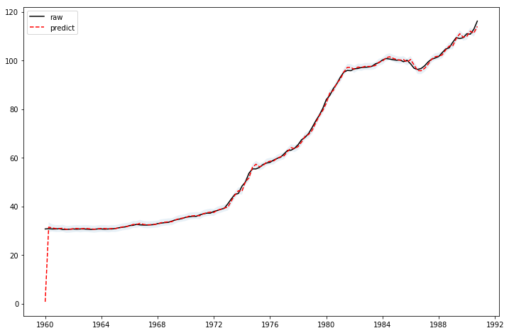

```python
fig,ax=plt.subplots(figsize=(12,8))
ax.plot(data.wpi,'k',label='raw')
ax.plot(arima_mod111fit.predict(),'r--',label='predict')
ci=arima_mod111fit.get_prediction().conf_int().iloc[1:,]
l,r=ci.iloc[:,0],ci.iloc[:,1]
ax.fill_between(ci.index,l,r,alpha=0.1)
ax.legend()
plt.show()
```

## 模型属性和方法

```python
for i in dir(arima_mod111fit):
    if i[0]!='_':
        print('arima_mod111fit.'+i)
        eval('arima_mod111fit.'+i)
```

```
arima_mod111fit.aic
```

```
278.7026613805318
```

```
arima_mod111fit.arfreq
```

```
array([0.])
```

```
arima_mod111fit.arparams
```

```
array([0.87422662])
```

```
arima_mod111fit.arroots
```

```
array([1.14386816])
```

```
arima_mod111fit.bic
```

```
289.9513988020215
```

```
arima_mod111fit.bse
```

```
intercept    0.067888
ar.L1        0.054543
ma.L1        0.100028
sigma2       0.053372
dtype: float64
```

```
arima_mod111fit.conf_int
```

```
<bound method LikelihoodModelResults.conf_int of <statsmodels.tsa.statespace.sarimax.SARIMAXResultsWrapper object at 0x00000168DEB9BC08>>
```

```
arima_mod111fit.cov_kwds
```

```
{'description': 'Covariance matrix calculated using the outer product of gradients (complex-step).'}
```

```
arima_mod111fit.cov_params
```

```
<bound method LikelihoodModelResults.cov_params of <statsmodels.tsa.statespace.sarimax.SARIMAXResultsWrapper object at 0x00000168DEB9BC08>>
```

```
arima_mod111fit.cov_params_approx
```

|  | intercept | ar.L1 | ma.L1 | sigma2 |
| --- | --- | --- | --- | --- |
| intercept | 0.003404 | -0.002895 | 0.004034 | 0.000046 |
| ar.L1 | -0.002895 | 0.004067 | -0.005470 | -0.000066 |
| ma.L1 | 0.004034 | -0.005470 | 0.014903 | 0.000032 |
| sigma2 | 0.000046 | -0.000066 | 0.000032 | 0.004495 |

```
arima_mod111fit.cov_params_default
```

|  | intercept | ar.L1 | ma.L1 | sigma2 |
| --- | --- | --- | --- | --- |
| intercept | 0.004609 | -0.003011 | 0.002640 | -0.000575 |
| ar.L1 | -0.003011 | 0.002975 | -0.003366 | 0.000188 |
| ma.L1 | 0.002640 | -0.003366 | 0.010006 | 0.000007 |
| sigma2 | -0.000575 | 0.000188 | 0.000007 | 0.002849 |

```
arima_mod111fit.cov_params_oim
```

|  | intercept | ar.L1 | ma.L1 | sigma2 |
| --- | --- | --- | --- | --- |
| intercept | 0.003248 | -0.002791 | 0.003764 | 0.000045 |
| ar.L1 | -0.002791 | 0.004088 | -0.005380 | -0.000067 |
| ma.L1 | 0.003764 | -0.005380 | 0.014531 | 0.000033 |
| sigma2 | 0.000045 | -0.000067 | 0.000033 | 0.004495 |

```
arima_mod111fit.cov_params_opg
```

|  | intercept | ar.L1 | ma.L1 | sigma2 |
| --- | --- | --- | --- | --- |
| intercept | 0.004609 | -0.003011 | 0.002640 | -0.000575 |
| ar.L1 | -0.003011 | 0.002975 | -0.003366 | 0.000188 |
| ma.L1 | 0.002640 | -0.003366 | 0.010006 | 0.000007 |
| sigma2 | -0.000575 | 0.000188 | 0.000007 | 0.002849 |

```
arima_mod111fit.cov_params_robust
```

|  | intercept | ar.L1 | ma.L1 | sigma2 |
| --- | --- | --- | --- | --- |
| intercept | 0.002885 | -0.003483 | 0.005647 | 0.000576 |
| ar.L1 | -0.003483 | 0.006781 | -0.008965 | -0.000101 |
| ma.L1 | 0.005647 | -0.008965 | 0.021513 | -0.000059 |
| sigma2 | 0.000576 | -0.000101 | -0.000059 | 0.007368 |

```
arima_mod111fit.cov_params_robust_approx
```

|  | intercept | ar.L1 | ma.L1 | sigma2 |
| --- | --- | --- | --- | --- |
| intercept | 0.003172 | -0.003634 | 0.006222 | 0.000606 |
| ar.L1 | -0.003634 | 0.006528 | -0.009022 | -0.000138 |
| ma.L1 | 0.006222 | -0.009022 | 0.022433 | 0.000012 |
| sigma2 | 0.000606 | -0.000138 | 0.000012 | 0.007368 |

```
arima_mod111fit.cov_params_robust_oim
```

|  | intercept | ar.L1 | ma.L1 | sigma2 |
| --- | --- | --- | --- | --- |
| intercept | 0.002885 | -0.003483 | 0.005647 | 0.000576 |
| ar.L1 | -0.003483 | 0.006781 | -0.008965 | -0.000101 |
| ma.L1 | 0.005647 | -0.008965 | 0.021513 | -0.000059 |
| sigma2 | 0.000576 | -0.000101 | -0.000059 | 0.007368 |

```
arima_mod111fit.cov_type
```

```
'opg'
```

```
arima_mod111fit.data
```

```
<statsmodels.base.data.PandasData at 0x168deb9bbc8>
```

```
arima_mod111fit.data_in_cache
```

```
[]
```

```
arima_mod111fit.df_model
```

```
4
```

```
arima_mod111fit.df_resid
```

```
inf
```

```
arima_mod111fit.f_test
```

```
<bound method LikelihoodModelResults.f_test of <statsmodels.tsa.statespace.sarimax.SARIMAXResults object at 0x00000168DEB9BAC8>>
```

```
arima_mod111fit.filter_results
```

```
<statsmodels.tsa.statespace.kalman_smoother.SmootherResults at 0x168deb9e948>
```

```
arima_mod111fit.filtered_state
```

[output not shown]

[output cut: 71 more lines]

[output not shown]

```
arima_mod111fit.filtered_state_cov
```

[output not shown]

```
arima_mod111fit.fittedvalues
```

```
t
1960-01-01      0.749786
1960-04-01     31.449807
1960-07-01     31.122188
1960-10-01     30.867851
1961-01-01     30.862600
                 ...
1989-10-01    109.565333
1990-01-01    109.912121
1990-04-01    112.044809
1990-07-01    111.232380
1990-10-01    113.996828
Length: 124, dtype: float64
```

```
arima_mod111fit.forecast
```

```
<bound method MLEResults.forecast of <statsmodels.tsa.statespace.sarimax.SARIMAXResultsWrapper object at 0x00000168DEB9BC08>>
```

```
arima_mod111fit.forecasts
```

[output not shown]

```
arima_mod111fit.forecasts_error
```

[output not shown]

```
arima_mod111fit.forecasts_error_cov
```

[output not shown]

```
arima_mod111fit.forecasts_error_diffuse_cov
arima_mod111fit.get_forecast
```

```
<bound method MLEResults.get_forecast of <statsmodels.tsa.statespace.sarimax.SARIMAXResults object at 0x00000168DEB9BAC8>>
```

```
arima_mod111fit.get_prediction
```

```
<bound method SARIMAXResults.get_prediction of <statsmodels.tsa.statespace.sarimax.SARIMAXResults object at 0x00000168DEB9BAC8>>
```

```
arima_mod111fit.hqic
```

```
283.27187025228255
```

```
arima_mod111fit.impulse_responses
```

```
<bound method MLEResults.impulse_responses of <statsmodels.tsa.statespace.sarimax.SARIMAXResultsWrapper object at 0x00000168DEB9BC08>>
```

```
arima_mod111fit.info_criteria
```

```
<bound method MLEResults.info_criteria of <statsmodels.tsa.statespace.sarimax.SARIMAXResults object at 0x00000168DEB9BAC8>>
```

```
arima_mod111fit.initialize
```

```
<bound method Results.initialize of <statsmodels.tsa.statespace.sarimax.SARIMAXResults object at 0x00000168DEB9BAC8>>
```

```
arima_mod111fit.k_constant
```

```
0
```

```
arima_mod111fit.k_diffuse_states
```

```
0
```

```
arima_mod111fit.llf
```

```
-135.3513306902659
```

```
arima_mod111fit.llf_obs
```

[output not shown]

```
arima_mod111fit.load
```

```
<bound method ResultsWrapper.load of <class 'statsmodels.tsa.statespace.sarimax.SARIMAXResultsWrapper'>>
```

```
arima_mod111fit.loglikelihood_burn
```

```
1
```

```
arima_mod111fit.mafreq
```

```
array([0.])
```

```
arima_mod111fit.maparams
```

```
array([-0.41204495])
```

```
arima_mod111fit.maroots
```

```
array([2.42691966])
```

```
arima_mod111fit.model
```

```
<statsmodels.tsa.statespace.sarimax.SARIMAX at 0x168deb9b3c8>
```

```
arima_mod111fit.model_orders
```

```
{'trend': 1,
 'exog': 0,
 'ar': 1,
 'ma': 1,
 'seasonal_ar': 0,
 'seasonal_ma': 0,
 'reduced_ar': 1,
 'reduced_ma': 1,
 'exog_variance': 0,
 'measurement_variance': 0,
 'variance': 1}
```

```
arima_mod111fit.nobs
```

```
124
```

```
arima_mod111fit.nobs_diffuse
```

```
0
```

```
arima_mod111fit.nobs_effective
```

```
123
```

```
arima_mod111fit.normalized_cov_params
```

[output not shown]

# 有季节效应的非平稳模型

1. 直接差分，先消掉趋势。再按照周期来构建**疏系数模型**，季度数据，月度数据周期是一年
2. arima加法和乘法模型
3. x11季节调节模型
4. 指数平滑模型

```python
# Dataset
data = pd.read_stata(BytesIO(wpi1))
data.index = data.t
data['ln_wpi'] = np.log(data['wpi'])
data['D.ln_wpi'] = data['ln_wpi'].diff()#注意这里的时间之间差值是三个月，也就是季度数据，那我们在构建时只需构建滞后四期
```

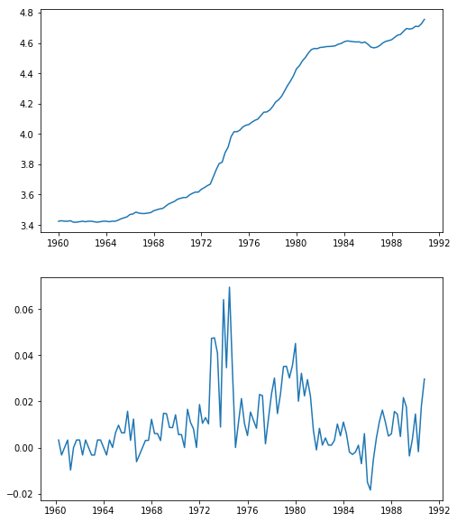

```python
fig=plt.figure(figsize=(8,10))
ax1=plt.subplot(211);ax1.plot(data.ln_wpi)
ax2=plt.subplot(212);ax2.plot(data['D.ln_wpi'])
```

## 第一种模型构建

```python
ar = 1          # this is the maximum degree specification
ma = (1,0,0,1)  # this is the lag polynomial specification
mod = tsa.SARIMAX(data['wpi'], trend='c', order=(ar,1,ma))#这里把关于时间t的函数就设置为常数c
modfit=mod.fit(disp=-1)
modfit.summary()#应为该序列并没有季节效应，四阶滞后参数检验不通过
```

Statespace Model Results

| Dep. Variable: | wpi | No. Observations: | 124 |
| --- | --- | --- | --- |
| Model: | SARIMAX(1, 1, (1, 4)) | Log Likelihood | -135.066 |
| Date: | Sat, 10 Apr 2021 | AIC | 280.132 |
| Time: | 21:22:47 | BIC | 294.193 |
| Sample: | 01-01-1960 | HQIC | 285.843 |
|  | - 10-01-1990 |  |  |
| Covariance Type: | opg |  |  |

|  | coef | std err | z | P>\|z\| | [0.025 | 0.975] |
| --- | --- | --- | --- | --- | --- | --- |
| intercept | 0.1260 | 0.092 | 1.370 | 0.171 | -0.054 | 0.306 |
| ar.L1 | 0.8325 | 0.081 | 10.231 | 0.000 | 0.673 | 0.992 |
| ma.L1 | -0.3710 | 0.108 | -3.447 | 0.001 | -0.582 | -0.160 |
| ma.L4 | 0.1087 | 0.094 | 1.157 | 0.247 | -0.075 | 0.293 |
| sigma2 | 0.5230 | 0.053 | 9.915 | 0.000 | 0.420 | 0.626 |

| Ljung-Box (Q): | 38.78 | Jarque-Bera (JB): | 12.03 |
| --- | --- | --- | --- |
| Prob(Q): | 0.53 | Prob(JB): | 0.00 |
| Heteroskedasticity (H): | 15.75 | Skew: | 0.27 |
| Prob(H) (two-sided): | 0.00 | Kurtosis: | 4.43 |

Warnings:  
[1] Covariance matrix calculated using the outer product of gradients (complex-step).

```python
data=pd.read_excel('./习题与案例数据/案例数据/A1_21.xlsx',index_col='time')
data
```

| time | x |
| --- | --- |
| 1948-01-01 | 446 |
| 1948-02-01 | 650 |
| 1948-03-01 | 592 |
| 1948-04-01 | 561 |
| 1948-05-01 | 491 |
| ... | ... |
| 1981-08-01 | 2975 |
| 1981-09-01 | 3064 |
| 1981-10-01 | 3092 |
| 1981-11-01 | 3063 |
| 1981-12-01 | 2991 |

408 rows × 1 columns

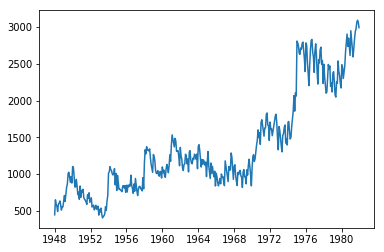

```python
plt.plot(data)
```

```python
select_arima_orderd_adf(data.x,3)
```

| 差分阶数 | p值 |
| --- | --- |
| 1 | 5.224534e-06 |
| 2 | 1.957925e-07 |
| 3 | 5.315701e-07 |

```python
ar=1#就设置为1
ma=[0]*12
ma[0]=1
ma[11]=1
mod=tsa.SARIMAX(data,order=(ar,1,ma))
modfit=mod.fit(disp=-1)
modfit.summary()
```

Statespace Model Results

| Dep. Variable: | x | No. Observations: | 408 |
| --- | --- | --- | --- |
| Model: | SARIMAX(1, 1, (1, 12)) | Log Likelihood | -2493.377 |
| Date: | Sat, 10 Apr 2021 | AIC | 4994.754 |
| Time: | 21:22:54 | BIC | 5010.790 |
| Sample: | 01-01-1948 | HQIC | 5001.100 |
|  | - 12-01-1981 |  |  |
| Covariance Type: | opg |  |  |

|  | coef | std err | z | P>\|z\| | [0.025 | 0.975] |
| --- | --- | --- | --- | --- | --- | --- |
| ar.L1 | -0.2673 | 0.100 | -2.679 | 0.007 | -0.463 | -0.072 |
| ma.L1 | 0.1064 | 0.096 | 1.103 | 0.270 | -0.083 | 0.295 |
| ma.L12 | 0.4273 | 0.048 | 8.887 | 0.000 | 0.333 | 0.522 |
| sigma2 | 1.219e+04 | 579.148 | 21.049 | 0.000 | 1.11e+04 | 1.33e+04 |

| Ljung-Box (Q): | 375.51 | Jarque-Bera (JB): | 132.26 |
| --- | --- | --- | --- |
| Prob(Q): | 0.00 | Prob(JB): | 0.00 |
| Heteroskedasticity (H): | 2.29 | Skew: | 0.72 |
| Prob(H) (two-sided): | 0.00 | Kurtosis: | 5.39 |

Warnings:  
[1] Covariance matrix calculated using the outer product of gradients (complex-step).

## ARIMA-加法模型

加法模型其实就是先获得平稳的模型，将不稳定因素减去，对剩下的因素构建适当的ARMA模型

```python
#导入数据
data=pd.read_excel('./习题与案例数据/案例数据/A1_20.xlsx',index_col='time')
data
```

| time | x |
| --- | --- |
| 1962-01-01 | 1.1 |
| 1962-04-01 | 0.5 |
| 1962-07-01 | 0.4 |
| 1962-10-01 | 0.7 |
| 1963-01-01 | 1.6 |
| ... | ... |
| 1990-10-01 | 6.6 |
| 1991-01-01 | 6.8 |
| 1991-04-01 | 6.0 |
| 1991-07-01 | 6.2 |
| 1991-10-01 | 6.2 |

120 rows × 1 columns

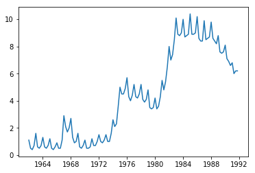

```python
plt.plot(data)
```

```python
#做一阶差分和4步差分，得到数据,因为这是季度数据
dx=data['x'].diff().dropna()
dx12=pd.Series([n-dx[::-1][i+4] for i,n in enumerate(dx[::-1]) if i+4<len(dx)])
```

```python
#检验平稳性和随机性
tsa.adfuller(dx12)
r,q,p=tsa.acf(dx12,fft=True,qstat=True)
np.c_[r[1:],q,p]
```

```
(-6.15621309726213,
 7.357953744299023e-08,
 3,
 111,
 {'1%': -3.490683082754047,
  '5%': -2.8879516565798817,
  '10%': -2.5808574442009578},
 57.66176611874175)
```

```
array([[ 4.22066251e-01,  2.10251984e+01,  4.53282432e-06],
       [ 1.88976812e-01,  2.52774828e+01,  3.24387684e-06],
       [ 7.24845218e-02,  2.59086671e+01,  9.96671089e-06],
       [-2.38843592e-01,  3.28235991e+01,  1.29804479e-06],
       [-2.38793298e-01,  3.97984557e+01,  1.63984012e-07],
       [-1.80874879e-01,  4.38368964e+01,  7.96352503e-08],
       [-1.94932404e-01,  4.85708939e+01,  2.75329616e-08],
       [-8.88521849e-02,  4.95636354e+01,  4.95665651e-08],
       [-5.97374814e-02,  5.00166077e+01,  1.06952006e-07],
       [ 2.17768244e-02,  5.00773769e+01,  2.58303768e-07],
       [ 2.17725542e-02,  5.01387063e+01,  5.91003399e-07],
       [-1.09621764e-01,  5.17084909e+01,  6.98214396e-07],
       [-2.03836243e-02,  5.17632992e+01,  1.48118422e-06],
       [-2.72508298e-02,  5.18622277e+01,  2.96709626e-06],
       [-1.20310925e-01,  5.38098011e+01,  2.82621187e-06],
       [ 1.71314533e-02,  5.38496887e+01,  5.48699630e-06],
       [ 5.63344292e-02,  5.42854066e+01,  8.91900867e-06],
       [-3.70409246e-02,  5.44757227e+01,  1.54678157e-05],
       [ 3.34272080e-02,  5.46323302e+01,  2.64565501e-05],
       [-5.67773727e-02,  5.50889037e+01,  3.98239366e-05],
       [-4.87304255e-02,  5.54288077e+01,  6.12018160e-05],
       [-7.49039463e-03,  5.54369250e+01,  1.02921942e-04],
       [-1.15397953e-01,  5.73844905e+01,  9.04122266e-05],
       [-1.17972793e-01,  5.94423041e+01,  7.65404775e-05],
       [-4.28970359e-02,  5.97174074e+01,  1.14349898e-04],
       [-6.39266238e-02,  6.03352207e+01,  1.51143632e-04],
       [ 5.67403641e-02,  6.08274702e+01,  2.05279762e-04],
       [ 1.22109796e-01,  6.31335029e+01,  1.59611818e-04],
       [ 8.42926928e-02,  6.42451453e+01,  1.77948161e-04],
       [ 1.39901237e-01,  6.73433341e+01,  1.09119067e-04],
       [ 2.38312186e-01,  7.64403073e+01,  1.03975215e-05],
       [ 2.14123950e-01,  8.38728276e+01,  1.56253569e-06],
       [ 1.36469084e-01,  8.69287224e+01,  9.62407575e-07],
       [ 7.75446317e-03,  8.69387110e+01,  1.59550939e-06],
       [-1.75615070e-01,  9.21257233e+01,  4.93164324e-07],
       [-1.93746705e-01,  9.85190259e+01,  1.01272609e-07],
       [-2.27914085e-01,  1.07479509e+02,  8.53842148e-09],
       [-9.94686998e-02,  1.09208393e+02,  8.27441070e-09],
       [ 1.02066788e-02,  1.09226836e+02,  1.42176837e-08],
       [-1.57033533e-02,  1.09271076e+02,  2.39135167e-08]])
```

```
{'bic':            0          1          2          3
 0  96.453316  80.919882  84.974043  80.342909
 1  78.398369  83.123195  87.789872  84.874616
 2  83.121046  87.865584  80.724535  83.286027
 3  87.847277  81.027281  85.840942  92.948794, 'bic_min_order': (1, 0)}
```

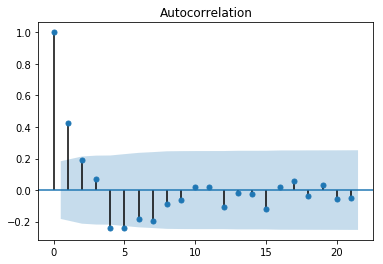

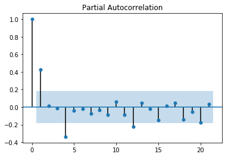

```python
#检验通过，在绘制自相关图加上order选择，判断最终定阶
plot_acf(dx12).show()
plot_pacf(dx12).show()
tsa.arma_order_select_ic(dx12,3,3,ic='bic')
```

```python
ar=[1,0,0,1]
mod=tsa.SARIMAX(data,order=(ar,1,0),seasonal_order=(0,1,0,4))
modfit=mod.fit(disp=-1)
modfit.summary()
```

Statespace Model Results

| Dep. Variable: | x | No. Observations: | 120 |
| --- | --- | --- | --- |
| Model: | SARIMAX((1, 4), 1, 0)x((), 1, 0, 4) | Log Likelihood | -26.697 |
| Date: | Sat, 10 Apr 2021 | AIC | 59.394 |
| Time: | 21:23:11 | BIC | 67.629 |
| Sample: | 01-01-1962 | HQIC | 62.736 |
|  | - 10-01-1991 |  |  |
| Covariance Type: | opg |  |  |

|  | coef | std err | z | P>\|z\| | [0.025 | 0.975] |
| --- | --- | --- | --- | --- | --- | --- |
| ar.L1 | 0.4448 | 0.051 | 8.680 | 0.000 | 0.344 | 0.545 |
| ar.L4 | -0.2720 | 0.068 | -3.975 | 0.000 | -0.406 | -0.138 |
| sigma2 | 0.0927 | 0.009 | 10.775 | 0.000 | 0.076 | 0.110 |

| Ljung-Box (Q): | 39.12 | Jarque-Bera (JB): | 27.57 |
| --- | --- | --- | --- |
| Prob(Q): | 0.51 | Prob(JB): | 0.00 |
| Heteroskedasticity (H): | 0.64 | Skew: | 0.30 |
| Prob(H) (two-sided): | 0.17 | Kurtosis: | 5.32 |

Warnings:  
[1] Covariance matrix calculated using the outer product of gradients (complex-step).

```python
modfit.predict(0,120)
```

```
1962-01-01    0.000000
1962-04-01    1.100000
1962-07-01    0.500000
1962-10-01    0.400000
1963-01-01    1.250000
                ...
1991-01-01    6.949265
1991-04-01    5.612139
1991-07-01    5.916173
1991-10-01    6.186753
1992-01-01    6.615064
Freq: QS-OCT, Length: 121, dtype: float64
```

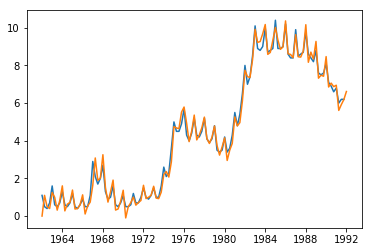

```python
ax=plt.subplot(111)
ax.plot(data['x'])
ax.plot(modfit.predict(0,120))
```

季节的加法模型和上面一个模型相比就是多了一个季节参数，也就是一个季节的k步差分

模型检验

都是通过的

略

## ARIMA-乘法模型

| time | x |
| --- | --- |
| 1948-01-01 | 446 |
| 1948-02-01 | 650 |
| 1948-03-01 | 592 |
| 1948-04-01 | 561 |
| 1948-05-01 | 491 |
| ... | ... |
| 1981-08-01 | 2975 |
| 1981-09-01 | 3064 |
| 1981-10-01 | 3092 |
| 1981-11-01 | 3063 |
| 1981-12-01 | 2991 |

408 rows × 1 columns

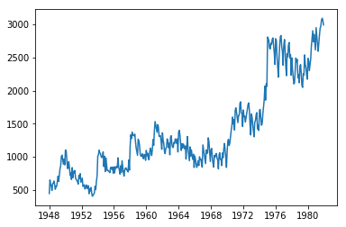

```python
data=pd.read_excel('./习题与案例数据/案例数据/A1_21.xlsx',index_col='time')
plt.plot(data)
data
```

```python
#先将趋势项和季节效应提取，检验序列是否是平稳非白噪声序列
#刚刚做一阶差分后已经提取了趋势效应
#再做12步差分，提取季节效应
dx=data['x'].diff().dropna()
dx12=pd.Series([n-dx[::-1][i+12] for i,n in enumerate(dx[::-1]) if i+12<len(dx)])
```

```python
#然后再确定是否是白噪声序列
r,q,p=tsa.acf(data['x'].diff().dropna(),fft=True,qstat=True,nlags=12)
np.c_[r[1:],q,p]
```

```
array([[-1.85749784e-01,  1.41464777e+01,  1.69113428e-04],
       [ 2.98935223e-03,  1.41501507e+01,  8.45928814e-04],
       [-2.60302718e-01,  4.20687586e+01,  3.87956739e-09],
       [-7.06041807e-02,  4.41278399e+01,  6.03523844e-09],
       [ 2.35100467e-01,  6.70153553e+01,  4.27733608e-13],
       [-1.54958260e-02,  6.71150341e+01,  1.59431485e-12],
       [ 2.03394043e-01,  8.43311106e+01,  1.79654981e-15],
       [-8.43815734e-02,  8.73016825e+01,  1.63938501e-15],
       [-2.42222914e-01,  1.11841148e+02,  6.20008961e-20],
       [-7.56589124e-02,  1.14241348e+02,  7.42517345e-20],
       [-1.13345720e-01,  1.19641833e+02,  2.14011551e-20],
       [ 6.13800469e-01,  2.78414249e+02,  1.57763769e-52]])
```

```
{'bic':              0            1            2            3
 0  4860.959171  4861.392903  4852.740094  4858.431293
 1  4859.319573  4859.251978  4857.639464  4863.045988
 2  4853.259759  4856.594373  4862.554521  4868.222488
 3  4857.194729  4862.560040  4856.715196  4860.269284,
 'bic_min_order': (0, 2)}
```

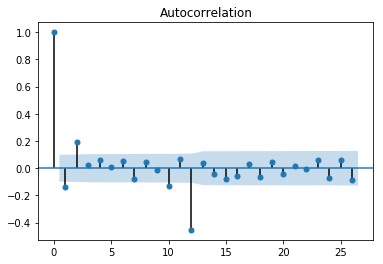

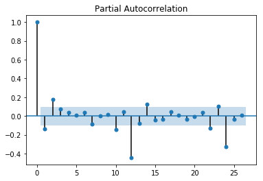

```python
#可以判断不是白噪声，为模型定阶

tsa.arma_order_select_ic(dx12,3,3,'bic')
plot_acf(dx12).show()
plot_pacf(dx12).show()
```

```python
# 模型尝试
ar=[0]*12
ar[0]=1
ar[-1]=1
ma=[0]*12
ma[0]=1
ma[1]=1
ma[-1]=1
## AR(1,12)
r,q,p=tsa.acf(tsa.SARIMAX(data,order=(ar,1,0),seasonal_order=(0,1,0,12)).fit(disp=-1).resid,fft=True,qstat=True,nlags=12)
np.c_[r[1:],q,p]
##MA(1,2,12)
r,q,p=tsa.acf(tsa.SARIMAX(data,order=(0,1,ma),seasonal_order=(0,1,0,12)).fit(disp=-1).resid,fft=True,qstat=True,nlags=12)
np.c_[r[1:],q,p]
##ARMA((1,12),(1,12))
r,q,p=tsa.acf(tsa.SARIMAX(data,order=(ar,1,ar),seasonal_order=(0,1,0,12)).fit(disp=-1).resid,fft=True,qstat=True,nlags=12)
np.c_[r[1:],q,p]
```

```
array([[ 2.62090931e-04,  2.82327771e-05,  9.95760498e-01],
       [ 1.59764475e-01,  1.05167024e+01,  5.20387781e-03],
       [ 6.39902758e-04,  1.05168715e+01,  1.46468835e-02],
       [ 6.61403669e-02,  1.23281943e+01,  1.50705147e-02],
       [ 2.91205772e-02,  1.26801913e+01,  2.65673310e-02],
       [ 5.60074868e-02,  1.39854907e+01,  2.97986615e-02],
       [-7.44858289e-02,  1.62999362e+01,  2.25130010e-02],
       [ 4.75763942e-02,  1.72465374e+01,  2.76418710e-02],
       [ 1.67598772e-03,  1.72477151e+01,  4.49751787e-02],
       [-8.53212637e-02,  2.03073916e+01,  2.64757342e-02],
       [ 4.68050874e-02,  2.12304722e+01,  3.10604125e-02],
       [-1.90425816e-01,  3.65484165e+01,  2.64346585e-04]])
```

```
array([[-4.38793784e-03,  7.91353530e-03,  9.29115246e-01],
       [ 1.08908145e-01,  4.89487265e+00,  8.65150990e-02],
       [-5.37913540e-02,  6.08999935e+00,  1.07312723e-01],
       [ 4.17548207e-02,  6.81189745e+00,  1.46168807e-01],
       [ 4.29923830e-02,  7.57912115e+00,  1.81007414e-01],
       [ 6.39358198e-02,  9.28012949e+00,  1.58425867e-01],
       [-6.26090674e-02,  1.09153417e+01,  1.42354643e-01],
       [ 2.17990649e-02,  1.11140700e+01,  1.95319236e-01],
       [-4.07478530e-02,  1.18101844e+01,  2.24222982e-01],
       [-5.96051715e-02,  1.33034217e+01,  2.07198464e-01],
       [ 1.16491739e-02,  1.33606016e+01,  2.70411346e-01],
       [-5.09339524e-02,  1.44564831e+01,  2.72512353e-01]])
```

```
array([[ 3.15982571e-01,  4.10370250e+01,  1.49372521e-10],
       [-5.88083875e-02,  4.24619648e+01,  6.01868337e-10],
       [-1.74572953e-01,  5.50495642e+01,  6.70101585e-12],
       [-8.21849192e-02,  5.78462709e+01,  8.21956756e-12],
       [ 1.09130349e-01,  6.27897199e+01,  3.21823058e-12],
       [ 1.49917833e-01,  7.21421520e+01,  1.48554920e-13],
       [ 1.77317263e-02,  7.22733120e+01,  5.12360612e-13],
       [-9.50309310e-02,  7.60500252e+01,  3.03874327e-13],
       [-1.88881390e-01,  9.10071964e+01,  1.02210118e-15],
       [-1.51868051e-01,  1.00700990e+02,  3.94492110e-17],
       [ 3.62650860e-01,  1.56116450e+02,  8.36001979e-28],
       [ 3.64378402e-01,  2.12202401e+02,  9.79513166e-39]])
```

再次回到之前的自相关图，因为均不截尾，所以构建ARMA(1,1)模型

在考虑季节自相关特征，考虑季节效应周期（这里是一年，12阶延迟）倍数的相关系数，也就是12,24等

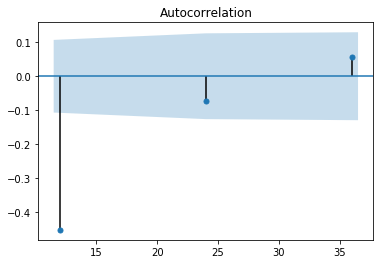

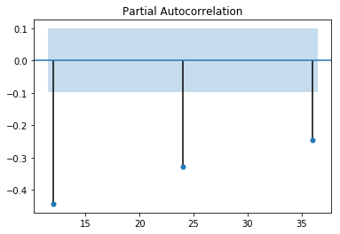

```python
plot_acf(dx12,lags=[i for i in range(12,48,12)]).show()
plot_pacf(dx12,lags=[i for i in range(12,48,12)]).show()
```

可以看到自相关系数延迟12阶显著非0，但是延迟24阶落入两倍标准差内。而偏相关系数延迟12阶和24阶都显著非0，认为自相关1阶截尾，偏自相关拖尾，所以是$ARIMA(1,1,1)\times(0,1,1)_{12}$

```python
#模型构建
mod=tsa.SARIMAX(data,order=(1,1,1),seasonal_order=(0,1,1,12)).fit(disp=-1)
mod.summary()
```

Statespace Model Results

| Dep. Variable: | x | No. Observations: | 408 |
| --- | --- | --- | --- |
| Model: | SARIMAX(1, 1, 1)x(0, 1, 1, 12) | Log Likelihood | -2327.076 |
| Date: | Sat, 10 Apr 2021 | AIC | 4662.153 |
| Time: | 21:23:49 | BIC | 4678.069 |
| Sample: | 01-01-1948 | HQIC | 4668.459 |
|  | - 12-01-1981 |  |  |
| Covariance Type: | opg |  |  |

|  | coef | std err | z | P>\|z\| | [0.025 | 0.975] |
| --- | --- | --- | --- | --- | --- | --- |
| ar.L1 | -0.7271 | 0.167 | -4.360 | 0.000 | -1.054 | -0.400 |
| ma.L1 | 0.6036 | 0.193 | 3.120 | 0.002 | 0.224 | 0.983 |
| ma.S.L12 | -0.7919 | 0.035 | -22.788 | 0.000 | -0.860 | -0.724 |
| sigma2 | 7444.7835 | 418.903 | 17.772 | 0.000 | 6623.750 | 8265.817 |

| Ljung-Box (Q): | 39.98 | Jarque-Bera (JB): | 96.63 |
| --- | --- | --- | --- |
| Prob(Q): | 0.47 | Prob(JB): | 0.00 |
| Heteroskedasticity (H): | 1.56 | Skew: | 0.69 |
| Prob(H) (two-sided): | 0.01 | Kurtosis: | 4.99 |

Warnings:  
[1] Covariance matrix calculated using the outer product of gradients (complex-step).

```python
# 模型显著性检验
r,q,p=tsa.acf(mod.resid,fft=True,qstat=True,nlags=12)
np.c_[r[1:],q,p]
```

```
array([[ 4.21220154e-02,  7.29235657e-01,  3.93131054e-01],
       [ 3.45447505e-02,  1.22091516e+00,  5.43102298e-01],
       [ 5.26569785e-03,  1.23236768e+00,  7.45252129e-01],
       [-5.54856194e-03,  1.24511513e+00,  8.70616308e-01],
       [ 8.40985550e-02,  4.18084466e+00,  5.23683554e-01],
       [ 4.87304329e-02,  5.16898472e+00,  5.22329615e-01],
       [-4.78427525e-02,  6.12382771e+00,  5.25367445e-01],
       [ 1.45962355e-02,  6.21292525e+00,  6.23394560e-01],
       [-3.75830490e-02,  6.80510717e+00,  6.57402303e-01],
       [-6.54153133e-02,  8.60364592e+00,  5.70085780e-01],
       [ 2.80827570e-02,  8.93594796e+00,  6.27804691e-01],
       [-4.38198976e-02,  9.74707998e+00,  6.38138285e-01]])
```

显著性检验通过，系数检验也通过

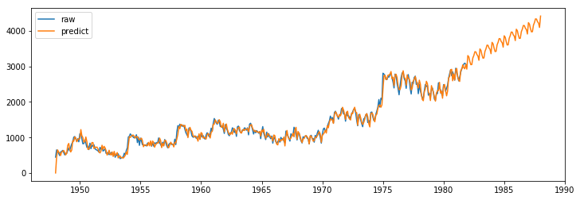

```python
fig,axes=plt.subplots(figsize=(12,4))
axes.plot(data,label='raw')
axes.plot(mod.predict(0,480),label='predict')
plt.legend()
```

## 季节调整模型

```python
data=pd.read_excel('./习题与案例数据/案例数据/A1_17.xlsx',index_col='time')
#tsa.x13_arima_select_order(data,maxorder=(2,2),maxdiff=(2,1))# x12a and x13as not found on path. Give the path, put them on PATH, or set the X12PATH or X13PATH environmental variable.
```

## 指数平滑模型

1. Holt线性趋势模型

Holt 在1957年把简单的指数平滑模型进行了延伸，能够预测包含趋势的数据，该方法包含一个预测方程和两个平滑方程（一个用于水平，另一个用于趋势）

\begin{align*} \text{Forecast equation}&& \hat{y}_{t+h|t} &= \ell_{t} + hb_{t} \\ \text{Level equation}&& \ell_{t} &= \alpha y_{t} + (1 - \alpha)(\ell_{t-1} + b_{t-1})\\ \text{Trend equation}&& b_{t} &= \beta^*(\ell_{t} - \ell_{t-1}) + (1 -\beta^*)b_{t-1} \end{align*}

1. 指数趋势模型

另外一种Holt 线性模型的变体是指数趋势模型，这时水平和趋势不是相加的，而是相乘

\begin{align*} \hat {y}_{t+h|t} &= \ell_{t} b_{t}^h\\ \ell_{t} &= \alpha y_{t} + (1 - \alpha)(\ell_{t-1} b_{t-1})\\ b_{t} &= \beta^*\frac{\ell_{t}}{ \ell_{t-1}} + (1 -\beta^*)b_{t-1} \end{align*}

1. 阻尼趋势模型

经验表明，Holt的线性模型和指数模型倾向于对未来预测值过高，特别是对于长期预测。Gardner 和 McKenzie (1985)引入了一种阻尼效应，倾向于在未来保持一个水平的线。包含阻尼的趋势被证明是一种非常有效的预测方法。

除了Holt的方法中的α和$\beta^*$，该方法还包含阻尼参数0<ϕ<1:

\begin{align*} \hat {y}_{t+h|t} &= \ell_{t} + (\phi+\phi^2 + \dots + \phi^{h}) b_{t} \\ \ell_{t} &= \alpha y_{t} + (1 - \alpha)(\ell_{t-1} + \phi b_{t-1})\\ b_{t} &= \beta^*(\ell_{t} - \ell_{t-1}) + (1 -\beta^*)\phi b_{t-1}. \end{align*}

如果 ϕ=1，这种方法与Holt的线性模型相同。对于在0到1的值， ϕ对趋势产生阻尼效应。实际上， 当 h→∞时对于任何的 0<ϕ<1预测值收敛于 lT+ϕbT/(1−ϕ)。 误差校正形式是：

\begin{align*} \ell_{t} &= \ell_{t-1} + \phi b_{t-1} + \alpha e_{t} \\ b_{t} &= \phi b_{t-1}+ \alpha \beta^*e_{t}. \end{align*}

1. 乘法阻尼趋势

Taylor(2003)引入了一种阻尼参数，建立了乘法阻尼趋势模型：

\begin{align*} \hat {y}_{t+h|t} &= \ell_{t}b_{t}^{(\phi+\phi^2 + \dots + \phi^{h})} \\ \ell_{t} &= \alpha y_{t} + (1 - \alpha)\ell_{t-1} b^\phi_{t-1}\\ b_{t} &= \beta^*\frac{\ell_{t}}{ \ell_{t-1}} + (1 -\beta^*)b_{t-1}^{\phi}. \end{align*}

这种方法的预测结果不像加法阻尼那么保守，误差校正形式是：

\begin{align*} \ell_{t} &= \ell_{t-1} b^\phi_{t-1}+\alpha e_{t}\\ b_{t} &= b^\phi_{t-1}+ \alpha \beta^*\frac{e_{t}}{\ell_{t-1}}. \end{align*}

1. holt三参数模型

三次指数平滑在二次指数平滑的基础上保留了季节性的信息，使得其可以预测带有季节性的时间序列。三次指数平滑添加了一个新的参数p来表示平滑后的趋势。

三次指数平滑有累加和累乘两种方法。

**季节加法模型**：

$a_0截距，b为斜率,\epsilon_t随机波动,服从N(0,\sigma^2)分布,c_t为t时刻有时间效应造成的序列偏差$

$$x_t=a_0+bt+c_t+\epsilon_t$$

假设每个季节的周期长度为m期，每一期的季节指数为$S_1,S_2,\dots,S_m$,不放假设t时刻为季节周期的第j期,则$c_t$可以表示为:$c_t=S_j+e_t e_t \sim N(0,\sigma^2_e)$,则模型可以写成如下递推公式:

$$x_t=a_0+b(t-1)+b+c_t+\epsilon_t=(x_{t-1}-c_{t-1}-\epsilon_{t-1})+b+\epsilon_t+(S_j+e_t)$$

不妨记：

$a(t-1)=x_{t-1}-c_{t-1}-\epsilon_{t-1}$

$b(t)=b+\epsilon_t$

$c(t)=S_j+e_t$

显然，$a(t-1)$是t-1时刻消除季节效应的序列截距项的无偏估计值，$b(t)$是t时刻斜率b的无偏估计值,c(t)是t时刻季节指数S_j的无偏估计值.

则：$x_t=a(t-1)+b(t)+c(t)$

Holt-Winters三参数指数模型就是分别使用指数平滑的方法，迭代递推参数$\hat{a}(t),\hat{b}(t)和\hat{c}_t$的值，递推公式如下:

$\hat{a}(t)=\alpha[x_t-c(t-m)]+(1-\alpha)[\hat(a)(t-1)+\hat(b)(t-1)]$

$\hat{b}(t)=\beta[\hat{a}(t)-\hat{a}(t-1)]+(1-\beta)\hat{b}(t-1)$

$\hat{c}(t)=\gamma[x_t-\hat{a}(t)]+(1-\gamma)c(t-m)$

式中，$x_t$为序列在t时刻得到的最新观察值；m是季节效应的周期长度；$\alpha,\beta,\gamma$均为平滑系数,满足$0<\alpha,\beta,\gamma<1$

使用holt-Winters三参数指数平滑加法公式，向前k期的预测值为:

$\hat{x}_{t+k}=\hat{a}(t)+\hat{b}(t)k+\hat{c}(t+k),\forall k \geq 1$

假设t+k期为季节周期的第j期,则$\hat{c}(t+k)=\hat{S}_k(j=1,2,3,\dots,m)$

**季节乘法模型**

对于乘法模型，序列通常可以表达为如下模型结构:

$x_t=(a_0+bt+\epsilon_t)c_t$

式中，$a_0$为截距；b为斜率.$\epsilon_t$为随机波动且$\epsilon_t\sim N(0,sigma^2)$;c_t为t时刻的季节效应；

假设每个季节的周期长度为m期，每一期的季节指数为$S_1,S_2,\dots,S_m$,不放假设t时刻为季节周期的第j期,则$c_t$可以表示为:$c_t=S_j+e_t e_t \sim N(0,\sigma^2_e)$,则模型可以写成如下递推公式:

$$x_t=[a_0+b(t-1)+b+\epsilon_t]c_t=[(x_{t-1}/c_{t-1}-\epsilon_{t-1})+b+\epsilon_t](S_j+e_t)$$

不妨记：

$a(t-1)=x_{t-1}/c_{t-1}-\epsilon_{t-1}$

$b(t)=b+\epsilon_t$

$c(t)=S_j+e_t$

显然，a(t-1)是t-1时刻消除季节效应的序列截距的无偏估计值，b(t)是t时刻序列斜率b的无偏估计值，c（t）是t时刻序列季节指数$S_j$的无偏估计值

则模型可以表示为：

$$x_t=[a(t-1)+b(t)]c(t)$$

式中三个参数的地推公式是:

$\hat{a}(t)=\alpha[x_t/c(t-m)]+(1-\alpha)[\hat(a)(t-1)+\hat(b)(t-1)]$

$\hat{b}(t)=\beta[\hat{a}(t)-\hat{a}(t-1)]+(1-\beta)\hat{b}(t-1)$

$\hat{c}(t)=\gamma[x_t/\hat{a}(t)]+(1-\gamma)c(t-m)$

式中，$x_t$为序列在t时刻得到的最新观察值；m是季节效应的周期长度；$\alpha,\beta,\gamma$均为平滑系数,满足$0<\alpha,\beta,\gamma<1$

使用holt-Winters三参数指数平滑加法公式，向前k期的预测值为:

$\hat{x}_{t+k}=[\hat{a}(t)+\hat{b}(t)k]\hat{c}(t+k),\forall k \geq 1$

假设t+k期为季节周期的第j期,则$\hat{c}(t+k)=\hat{S}_k(j=1,2,3,\dots,m)$

### 简单指数平滑模型

模型没有长期趋势和季节效应

```python
#Here we run three variants of simple exponential smoothing:

#In fit1 we do not use the auto optimization but instead choose to explicitly provide the model with the  α=0.2  parameter
#In fit2 as above we choose an  α=0.6
#In fit3 we allow statsmodels to automatically find an optimized  α  value for us. This is the recommended approach.

data=pd.read_excel('./习题与案例数据/案例数据/A1_18.xlsx')
data.index=pd.date_range('1949','1999',freq='a')
data.index
del data['year']
data
```

```
DatetimeIndex(['1949-12-31', '1950-12-31', '1951-12-31', '1952-12-31',
               '1953-12-31', '1954-12-31', '1955-12-31', '1956-12-31',
               '1957-12-31', '1958-12-31', '1959-12-31', '1960-12-31',
               '1961-12-31', '1962-12-31', '1963-12-31', '1964-12-31',
               '1965-12-31', '1966-12-31', '1967-12-31', '1968-12-31',
               '1969-12-31', '1970-12-31', '1971-12-31', '1972-12-31',
               '1973-12-31', '1974-12-31', '1975-12-31', '1976-12-31',
               '1977-12-31', '1978-12-31', '1979-12-31', '1980-12-31',
               '1981-12-31', '1982-12-31', '1983-12-31', '1984-12-31',
               '1985-12-31', '1986-12-31', '1987-12-31', '1988-12-31',
               '1989-12-31', '1990-12-31', '1991-12-31', '1992-12-31',
               '1993-12-31', '1994-12-31', '1995-12-31', '1996-12-31',
               '1997-12-31', '1998-12-31'],
              dtype='datetime64[ns]', freq='A-DEC')
```

|  | temp |
| --- | --- |
| 1949-12-31 | 38.8 |
| 1950-12-31 | 35.6 |
| 1951-12-31 | 38.3 |
| 1952-12-31 | 39.6 |
| 1953-12-31 | 37.0 |
| 1954-12-31 | 33.4 |
| 1955-12-31 | 39.6 |
| 1956-12-31 | 34.6 |
| 1957-12-31 | 36.2 |
| 1958-12-31 | 37.6 |
| 1959-12-31 | 36.8 |
| 1960-12-31 | 38.1 |
| 1961-12-31 | 40.6 |
| 1962-12-31 | 37.1 |
| 1963-12-31 | 39.0 |
| 1964-12-31 | 37.5 |
| 1965-12-31 | 38.5 |
| 1966-12-31 | 37.5 |
| 1967-12-31 | 35.8 |
| 1968-12-31 | 40.1 |
| 1969-12-31 | 35.9 |
| 1970-12-31 | 35.3 |
| 1971-12-31 | 35.2 |
| 1972-12-31 | 39.5 |
| 1973-12-31 | 37.5 |
| 1974-12-31 | 35.8 |
| 1975-12-31 | 38.4 |
| 1976-12-31 | 35.0 |
| 1977-12-31 | 34.1 |
| 1978-12-31 | 37.5 |
| 1979-12-31 | 35.9 |
| 1980-12-31 | 35.1 |
| 1981-12-31 | 38.1 |
| 1982-12-31 | 37.3 |
| 1983-12-31 | 37.2 |
| 1984-12-31 | 36.1 |
| 1985-12-31 | 35.1 |
| 1986-12-31 | 38.5 |
| 1987-12-31 | 36.1 |
| 1988-12-31 | 38.1 |
| 1989-12-31 | 35.8 |
| 1990-12-31 | 37.5 |
| 1991-12-31 | 35.7 |
| 1992-12-31 | 37.5 |
| 1993-12-31 | 35.8 |
| 1994-12-31 | 37.2 |
| 1995-12-31 | 35.0 |
| 1996-12-31 | 36.0 |
| 1997-12-31 | 38.2 |
| 1998-12-31 | 37.2 |

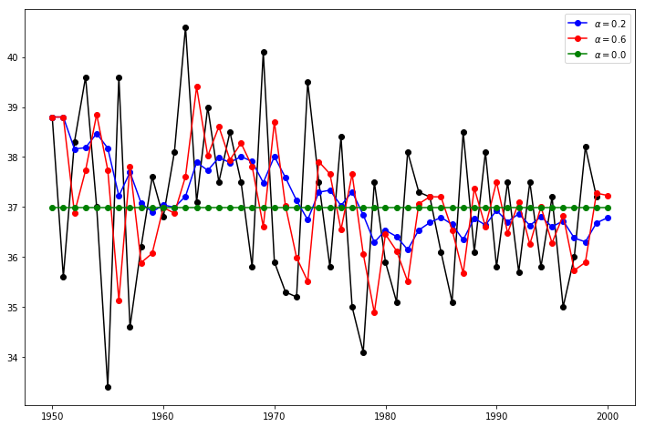

```python
fit1 = tsa.SimpleExpSmoothing(data).fit(smoothing_level=0.2,optimized=False)
fcast1 = fit1.predict(0,50)
fit2 = tsa.SimpleExpSmoothing(data).fit(smoothing_level=0.6,optimized=False)
fcast2 = fit2.predict(0,50)
fit3 = tsa.SimpleExpSmoothing(data).fit()
fcast3 = fit3.predict(0,50)

fig,ax=plt.subplots(figsize=(12,8))
ax.plot(data,marker='o', color='black')
ax.plot(fcast1,marker='o',  color='blue', label=r'$\alpha=0.2$')
ax.plot(fcast2,marker='o',  color='red', label=r'$\alpha=0.6$')
ax.plot(fcast3,marker='o',  color='green', label=r'$\alpha=%s$'%fit3.model.params['smoothing_level'])
ax.legend()
plt.show()
```

### 指数平滑-holt两参数

对于含有线性趋势的序列进行预测

```python
data=pd.read_excel('./习题与案例数据/案例数据/A1_19.xlsx')
data.index=pd.date_range('1898','1969',freq='a')
del data['year']
data
```

|  | water |
| --- | --- |
| 1898-12-31 | 402.8 |
| 1899-12-31 | 421.3 |
| 1900-12-31 | 431.2 |
| 1901-12-31 | 426.2 |
| 1902-12-31 | 425.5 |
| ... | ... |
| 1964-12-31 | 567.1 |
| 1965-12-31 | 499.3 |
| 1966-12-31 | 493.6 |
| 1967-12-31 | 533.7 |
| 1968-12-31 | 581.1 |

71 rows × 1 columns

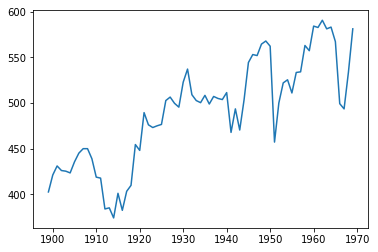

```python
plt.plot(data)
```

[output not shown]

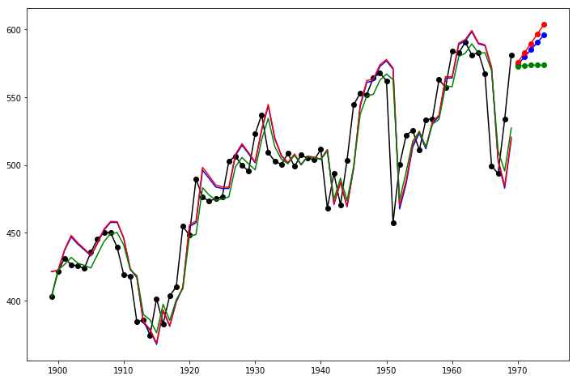

```python
fit1 = tsa.Holt(data).fit(smoothing_level=0.8, smoothing_slope=0.2, optimized=False)
fcast1 = fit1.forecast(5)
fit2 = tsa.Holt(data, exponential=True).fit(smoothing_level=0.8, smoothing_slope=0.2, optimized=False)
fcast2 = fit2.forecast(5)
fit3 = tsa.Holt(data, damped=True).fit(smoothing_level=0.8, smoothing_slope=0.2)
fcast3 = fit3.forecast(5)

fig,ax=plt.subplots(figsize=(12,8))
ax.plot(data,color="black", marker="o")
ax.plot(fit1.fittedvalues, color='blue')
ax.plot(fcast1, color='blue', marker="o")
ax.plot(fit2.fittedvalues,color='red')
ax.plot(fcast2, color='red', marker="o")
ax.plot(fit3.fittedvalues, color='green')
ax.plot(fcast3, color='green', marker="o")
plt.show()
```

Seasonally adjusted data

Lets look at some seasonally adjusted livestock data. We fit five Holt's models. The below table allows us to compare results when we use exponential versus additive and damped versus non-damped.

Note: fit4 does not allow the parameter ϕ to be optimized by providing a fixed value of ϕ=0.98

```python
data = [263.9177,  268.3072,  260.6626,  266.6394,  277.5158,  283.834 , 290.309 ,  292.4742,  300.8307,  309.2867,  318.3311,  329.3724, 338.884 ,  339.2441,  328.6006,  314.2554,  314.4597,  321.4138, 329.7893,  346.3852,  352.2979,  348.3705,  417.5629,  417.1236, 417.7495,  412.2339,  411.9468,  394.6971,  401.4993,  408.2705, 414.2428]
index= pd.date_range(start='1970', end='2001', freq='A')
livestock2 = pd.Series(data, index)
data = [407.9979 ,  403.4608,  413.8249,  428.105 ,  445.3387,  452.9942, 455.7402]
index= pd.date_range(start='2001', end='2008', freq='A')
livestock3 = pd.Series(data, index)
fit1 = tsa.SimpleExpSmoothing(livestock2).fit()
fit2 = tsa.Holt(livestock2).fit()
fit3 = tsa.Holt(livestock2,exponential=True).fit()
fit4 = tsa.Holt(livestock2,damped=True).fit(damping_slope=0.98)
fit5 = tsa.Holt(livestock2,exponential=True,damped=True).fit()
params = ['smoothing_level', 'smoothing_slope', 'damping_slope', 'initial_level', 'initial_slope']
results=pd.DataFrame(np.zeros((6,5)),index=[r"$\alpha$",r"$\beta$",r"$\phi$",r"$l_0$","$b_0$","SSE"] ,columns=['SES', "Holt's","Exponential", "Additive", "Multiplicative"])
results["SES"] =            [fit1.params[p] for p in params] + [fit1.sse]
results["Holt's"] =         [fit2.params[p] for p in params] + [fit2.sse]
results["Exponential"] =    [fit3.params[p] for p in params] + [fit3.sse]
results["Additive"] =       [fit4.params[p] for p in params] + [fit4.sse]
results["Multiplicative"] = [fit5.params[p] for p in params] + [fit5.sse]
results
```

|  | SES | Holt's | Exponential | Additive | Multiplicative |
| --- | --- | --- | --- | --- | --- |
| $\alpha$ | 1.000000 | 0.974306 | 0.977633 | 0.978847 | 0.974911 |
| $\beta$ | NaN | 0.000000 | 0.000000 | 0.000000 | 0.000000 |
| $\phi$ | NaN | NaN | NaN | 0.980000 | 0.981646 |
| $l_0$ | 263.917700 | 258.882647 | 260.341560 | 257.357648 | 258.951730 |
| $b_0$ | NaN | 5.010775 | 1.013780 | 6.644538 | 1.038145 |
| SSE | 6761.350218 | 6004.138200 | 6104.194746 | 6036.555004 | 6081.995045 |

Plots of Seasonally Adjusted Data The following plots allow us to evaluate the level and slope/trend components of the above table's fits.

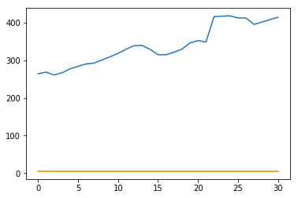

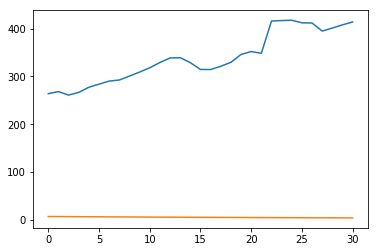

```
Figure 7.4: Level and slope components for Holt’s linear trend method and the additive damped trend method.
```

```python
for fit in [fit2,fit4]:
    plt.plot(pd.DataFrame(np.c_[fit.level,fit.slope]).rename(columns={0:'level',1:'slope'}))
    plt.show()
print('Figure 7.4: Level and slope components for Holt’s linear trend method and the additive damped trend method.')
```

Comparison¶

Here we plot a comparison Simple Exponential Smoothing and Holt's Methods for various additive, exponential and damped combinations. All of the models parameters will be optimized by statsmodels.

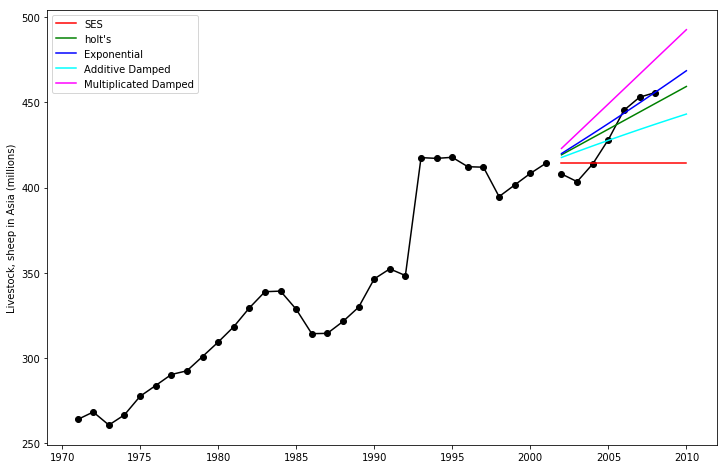

```
Figure 7.5: Forecasting livestock, sheep in Asia: comparing forecasting performance of non-seasonal methods.
```

```python
fit1 = tsa.SimpleExpSmoothing(livestock2).fit()
fcast1 = fit1.forecast(9)
fit2 = tsa.Holt(livestock2).fit()
fcast2 = fit2.forecast(9)
fit3 = tsa.Holt(livestock2, exponential=True).fit()
fcast3 = fit3.forecast(9)
fit4 = tsa.Holt(livestock2, damped=True).fit(damping_slope=0.98)
fcast4 = fit4.forecast(9)
fit5 = tsa.Holt(livestock2, exponential=True, damped=True).fit()
fcast5 = fit5.forecast(9)
fig,ax=plt.subplots(figsize=(12,8))
ax .plot(livestock2,color="black", marker="o")
ax.plot(livestock3 ,color="black", marker="o")
ax.plot(fcast1, color='red',label='SES')
ax.plot(fcast2, color='green',label="holt's")
ax.plot( fcast3,color='blue',label="Exponential")
ax.plot( fcast4,color='cyan',label="Additive Damped")
ax.plot( fcast5,color='magenta',label='Multiplicated Damped')
ax.set_ylabel('Livestock, sheep in Asia (millions)')
plt.legend()
plt.show()
print('Figure 7.5: Forecasting livestock, sheep in Asia: comparing forecasting performance of non-seasonal methods.')
```

### holt-winters三参数季节加法和乘法模型

`tsa.ExponentialSmoothing(data,seasonal_periods,trend='add'或'mul',seasonal='add'或'mut')`#seasonal选项决定了加法还是乘法模型

```python
help(tsa.ExponentialSmoothing)
```

[output not shown]

[output cut: 137 more lines]

[output not shown]

```
Holt's Winters Seasonal
Finally we are able to run full Holt's Winters Seasonal Exponential Smoothing including a trend component and a seasonal component. statsmodels allows for all the combinations including as shown in the examples below:

fit1 additive trend, additive seasonal of period season_length=4 and the use of a Box-Cox transformation.
fit2 additive trend, multiplicative seasonal of period season_length=4 and the use of a Box-Cox transformation..
fit3 additive damped trend, additive seasonal of period season_length=4 and the use of a Box-Cox transformation.
fit4 additive damped trend, multiplicative seasonal of period season_length=4 and the use of a Box-Cox transformation.
The plot shows the results and forecast for fit1 and fit2. The table allows us to compare the results and parameterizations.
```

```python
data = [41.7275,  24.0418,  32.3281,  37.3287,  46.2132,  29.3463, 36.4829,  42.9777,  48.9015,  31.1802,  37.7179,  40.4202, 51.2069,  31.8872,  40.9783,  43.7725,  55.5586,  33.8509, 42.0764,  45.6423,  59.7668,  35.1919,  44.3197,  47.9137]
index= pd.date_range(start='2005', end='2010-Q4', freq='QS-OCT')
aust = pd.Series(data, index)
```

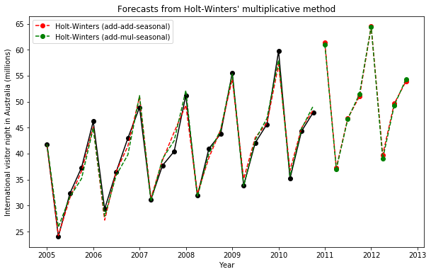

```
Figure 7.6: Forecasting international visitor nights in Australia using Holt-Winters method with both additive and multiplicative seasonality.
```

|  | Additive | Multiplicative | Additive Dam | Multiplica Dam |
| --- | --- | --- | --- | --- |
| $\alpha$ | 4.546258e-01 | 3.659123e-01 | 3.231104e-08 | 0.000182 |
| $\beta$ | 1.634586e-08 | 6.701126e-18 | 3.081400e-08 | 0.000182 |
| $\phi$ | NaN | NaN | 9.453152e-01 | 0.913648 |
| $\gamma$ | 5.244178e-01 | 9.705372e-12 | 7.167742e-06 | 0.000000 |
| $l_0$ | 1.421751e+01 | 1.454863e+01 | 1.418138e+01 | 14.534854 |
| $b_0$ | 1.307802e-01 | 1.661316e-01 | 2.380511e-01 | 0.484783 |
| SSE | 5.001656e+01 | 4.307003e+01 | 3.531783e+01 | 39.710958 |

```python
fit1 = tsa.ExponentialSmoothing(aust, seasonal_periods=4, trend='add', seasonal='add').fit(use_boxcox=True)
fit2 = tsa.ExponentialSmoothing(aust, seasonal_periods=4, trend='add', seasonal='mul').fit(use_boxcox=True)
fit3 = tsa.ExponentialSmoothing(aust, seasonal_periods=4, trend='add', seasonal='add', damped=True).fit(use_boxcox=True)
fit4 = tsa.ExponentialSmoothing(aust, seasonal_periods=4, trend='add', seasonal='mul', damped=True).fit(use_boxcox=True)
results=pd.DataFrame(np.zeros((7,4)),index=[r"$\alpha$",r"$\beta$",r"$\phi$",r"$\gamma$",r"$l_0$","$b_0$","SSE"],columns=["Additive","Multiplicative","Additive Dam","Multiplica Dam"])
params = ['smoothing_level', 'smoothing_slope', 'damping_slope', 'smoothing_seasonal', 'initial_level', 'initial_slope']
results["Additive"]       = [fit1.params[p] for p in params] + [fit1.sse]
results["Multiplicative"] = [fit2.params[p] for p in params] + [fit2.sse]
results["Additive Dam"]   = [fit3.params[p] for p in params] + [fit3.sse]
results["Multiplica Dam"] = [fit4.params[p] for p in params] + [fit4.sse]

fig,ax=plt.subplots(figsize=(10,6))
ax .plot(aust,marker='o', color='black' )
ax.set_ylabel("International visitor night in Australia (millions)")
ax.set_xlabel("Year")
ax.set_title("Forecasts from Holt-Winters' multiplicative method")
ax.plot(fit1.fittedvalues, ls='--', color='red')
ax.plot(fit2.fittedvalues, ls='--', color='green')
ax.plot(fit1.forecast(8), ls='--', marker='o', color='red', label='Holt-Winters (add-add-seasonal)')
ax.plot(fit2.forecast(8), ls='--', marker='o', color='green',label='Holt-Winters (add-mul-seasonal)')
plt.legend()
plt.show()
print("Figure 7.6: Forecasting international visitor nights in Australia using Holt-Winters method with both additive and multiplicative seasonality.")

results
```

The Internals It is possible to get at the internals of the Exponential Smoothing models.

Here we show some tables that allow you to view side by side the original values $y_t$ , the level $l_t$ , the trend $b_t$ , the season $s_t$ and the fitted values $\hat{y}_t$ .

```python
df = pd.DataFrame(np.c_[aust, fit1.level, fit1.slope, fit1.season, fit1.fittedvalues],
                  columns=[r'$y_t$',r'$l_t$',r'$b_t$',r'$s_t$',r'$\hat{y}_t$'],index=aust.index)
df.append(fit1.forecast(8).rename(r'$\hat{y}_t$').to_frame(), sort=True)
```

|  | $\hat{y}_t$ | $b_t$ | $l_t$ | $s_t$ | $y_t$ |
| --- | --- | --- | --- | --- | --- |
| 2005-01-01 | 41.721215 | -34.969355 | 49.317641 | -7.593355 | 41.7275 |
| 2005-04-01 | 24.190230 | -35.452819 | 49.932455 | -25.834685 | 24.0418 |
| 2005-07-01 | 31.460507 | -36.532825 | 51.126190 | -19.183004 | 32.3281 |
| 2005-10-01 | 36.634747 | -37.397689 | 52.210159 | -15.209769 | 37.3287 |
| 2006-01-01 | 45.097771 | -38.467268 | 53.476787 | -7.837229 | 46.2132 |
| 2006-04-01 | 27.191784 | -40.276317 | 55.513864 | -27.017364 | 29.3463 |
| 2006-07-01 | 36.544233 | -40.625063 | 56.224501 | -19.713874 | 36.4829 |
| 2006-10-01 | 41.449470 | -42.041800 | 57.766129 | -15.523362 | 42.9777 |
| 2007-01-01 | 50.934532 | -41.543834 | 57.536773 | -7.588696 | 48.9015 |
| 2007-04-01 | 31.418265 | -42.197870 | 58.151045 | -26.874311 | 31.1802 |
| 2007-07-01 | 38.718351 | -42.303520 | 58.363042 | -20.191961 | 37.7179 |
| 2007-10-01 | 44.140653 | -41.085817 | 57.181928 | -14.982846 | 40.4202 |
| 2008-01-01 | 49.315801 | -42.961548 | 58.853067 | -8.619920 | 51.2069 |
| 2008-04-01 | 32.307035 | -43.186594 | 59.367061 | -27.309231 | 31.8872 |
| 2008-07-01 | 39.207484 | -44.827063 | 61.095687 | -20.925640 | 40.9783 |
| 2008-10-01 | 44.551298 | -44.899537 | 61.462251 | -17.319979 | 43.7725 |
| 2009-01-01 | 54.358133 | -46.192301 | 62.816914 | -7.881709 | 55.5586 |
| 2009-04-01 | 35.153884 | -45.980242 | 62.832235 | -28.447956 | 33.8509 |
| 2009-07-01 | 43.066515 | -46.228183 | 63.082736 | -20.550728 | 42.0764 |
| 2009-10-01 | 45.871197 | -46.852581 | 63.748943 | -17.997893 | 45.6423 |
| 2010-01-01 | 57.166649 | -48.770485 | 65.777689 | -7.372215 | 59.7668 |
| 2010-04-01 | 36.761415 | -48.308407 | 65.650109 | -29.816926 | 35.1919 |
| 2010-07-01 | 44.932523 | -48.798730 | 66.119529 | -21.517568 | 44.3197 |
| 2010-10-01 | 48.399603 | -49.269891 | 66.667513 | -18.522367 | 47.9137 |
| 2011-01-01 | 61.338004 | NaN | NaN | NaN | NaN |
| 2011-04-01 | 37.242913 | NaN | NaN | NaN | NaN |
| 2011-07-01 | 46.842710 | NaN | NaN | NaN | NaN |
| 2011-10-01 | 51.005356 | NaN | NaN | NaN | NaN |
| 2012-01-01 | 64.470967 | NaN | NaN | NaN | NaN |
| 2012-04-01 | 39.777051 | NaN | NaN | NaN | NaN |
| 2012-07-01 | 49.636039 | NaN | NaN | NaN | NaN |
| 2012-10-01 | 53.901669 | NaN | NaN | NaN | NaN |

```python
df = pd.DataFrame(np.c_[aust, fit2.level, fit2.slope, fit2.season, fit2.fittedvalues],
                  columns=[r'$y_t$',r'$l_t$',r'$b_t$',r'$s_t$',r'$\hat{y}_t$'],index=aust.index)
df.append(fit2.forecast(8).rename(r'$\hat{y}_t$').to_frame(), sort=True)
```

|  | $\hat{y}_t$ | $b_t$ | $l_t$ | $s_t$ | $y_t$ |
| --- | --- | --- | --- | --- | --- |
| 2005-01-01 | 41.860256 | -36.532222 | 51.246984 | 0.815871 | 41.7275 |
| 2005-04-01 | 25.838610 | -35.868807 | 50.738675 | 0.495361 | 24.0418 |
| 2005-07-01 | 31.659323 | -37.285903 | 52.062842 | 0.612972 | 32.3281 |
| 2005-10-01 | 35.189636 | -39.171170 | 54.189365 | 0.664165 | 37.3287 |
| 2006-01-01 | 44.929137 | -40.308071 | 55.708228 | 0.815030 | 46.2132 |
| 2006-04-01 | 27.933669 | -42.089577 | 57.758593 | 0.493042 | 29.3463 |
| 2006-07-01 | 35.824394 | -43.102570 | 59.129556 | 0.610078 | 36.4829 |
| 2006-10-01 | 39.768659 | -45.646232 | 61.909513 | 0.661689 | 42.9777 |
| 2007-01-01 | 51.174545 | -45.123562 | 61.858836 | 0.813571 | 48.9015 |
| 2007-04-01 | 30.814509 | -46.410933 | 63.137686 | 0.490286 | 31.1802 |
| 2007-07-01 | 39.009207 | -46.389041 | 63.329916 | 0.608210 | 37.7179 |
| 2007-10-01 | 42.486041 | -46.173405 | 63.146302 | 0.660426 | 40.4202 |
| 2008-01-01 | 52.174350 | -46.762004 | 63.704315 | 0.813364 | 51.2069 |
| 2008-04-01 | 31.677371 | -47.838278 | 64.873425 | 0.489542 | 31.8872 |
| 2008-07-01 | 40.035793 | -49.241989 | 66.470507 | 0.607660 | 40.9783 |
| 2008-10-01 | 44.515956 | -49.577850 | 67.068109 | 0.659565 | 43.7725 |
| 2009-01-01 | 55.343501 | -50.604967 | 68.192465 | 0.812746 | 55.5586 |
| 2009-04-01 | 33.773172 | -51.518074 | 69.287512 | 0.487867 | 33.8509 |
| 2009-07-01 | 42.644271 | -52.028198 | 69.973592 | 0.606360 | 42.0764 |
| 2009-10-01 | 46.778450 | -52.313589 | 70.368612 | 0.658677 | 45.6423 |
| 2010-01-01 | 58.009276 | -54.096698 | 72.214632 | 0.812268 | 59.7668 |
| 2010-04-01 | 35.648429 | -54.502798 | 72.912723 | 0.486508 | 35.1919 |
| 2010-07-01 | 44.784383 | -55.166772 | 73.686275 | 0.605385 | 44.3197 |
| 2010-10-01 | 49.174485 | -55.392542 | 74.032938 | 0.657808 | 47.9137 |
| 2011-01-01 | 60.967615 | NaN | NaN | NaN | NaN |
| 2011-04-01 | 36.993898 | NaN | NaN | NaN | NaN |
| 2011-07-01 | 46.712479 | NaN | NaN | NaN | NaN |
| 2011-10-01 | 51.482819 | NaN | NaN | NaN | NaN |
| 2012-01-01 | 64.456507 | NaN | NaN | NaN | NaN |
| 2012-04-01 | 39.017313 | NaN | NaN | NaN | NaN |
| 2012-07-01 | 49.291842 | NaN | NaN | NaN | NaN |
| 2012-10-01 | 54.320157 | NaN | NaN | NaN | NaN |

Finally lets look at the levels, slopes/trends and seasonal components of the models.

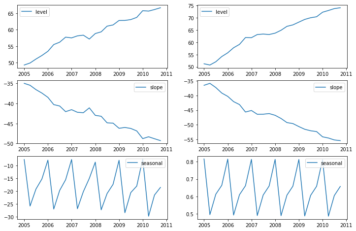

```python
states1 = pd.DataFrame(np.c_[fit1.level, fit1.slope, fit1.season], columns=['level','slope','seasonal'], index=aust.index)
states2 = pd.DataFrame(np.c_[fit2.level, fit2.slope, fit2.season], columns=['level','slope','seasonal'], index=aust.index)
fig, [[ax1, ax4],[ax2, ax5], [ax3, ax6]] = plt.subplots(3, 2, figsize=(12,8))
ax1.plot(states1[['level']],label='level')
ax1.legend()
ax2.plot(states1[['slope']],label='slope')
ax2.legend()
ax3.plot(states1[['seasonal']],label='seasonal')
ax3.legend()
ax4.plot(states2[['level']],label='level')
ax4.legend()
ax5.plot(states2[['slope']],label='slope')
ax5.legend()
ax6.plot(states2[['seasonal']],label='seasonal')
ax6.legend()
plt.show()
```

# examples参考

[ARMA模型，讲了平稳性检验，随机性检验，相关图绘制，模型定阶和构建，假设的检验，预测](https://www.statsmodels.org/v0.10.1/examples/notebooks/generated/tsa_arma_0.html)

[ARIMA模型,讲了只有趋势项的情形，以及疏系数构建，以及ARIMA加法和乘法模型](https://www.statsmodels.org/v0.10.1/examples/notebooks/generated/statespace_sarimax_stata.html)

[指数平滑的例子,包括简单指数平滑，holt两参数平滑（无季节效应），holt三参数季节加法和乘法模型](https://www.statsmodels.org/v0.10.1/examples/notebooks/generated/exponential_smoothing.html)

ARIMA Example 4: ARMAX (Friedman)

This model demonstrates the use of explanatory variables (the X part of ARMAX). When exogenous regressors are included, the SARIMAX module uses the concept of "regression with SARIMA errors" (see http://robjhyndman.com/hyndsight/arimax/ for details of regression with ARIMA errors versus alternative specifications), so that the model is specified as:

$$y_t = \beta_t x_t + u_t \\ \phi_p (L) \tilde \phi_P (L^s) \Delta^d \Delta_s^D u_t = A(t) + \theta_q (L) \tilde \theta_Q (L^s) \epsilon_t$$

Notice that the first equation is just a linear regression, and the second equation just describes the process followed by the error component as SARIMA (as was described in example 3). One reason for this specification is that the estimated parameters have their natural interpretations.

This specification nests many simpler specifications. For example, regression with AR(2) errors is:

$$y_t = \beta_t x_t + u_t \\ (1 - \phi_1 L - \phi_2 L^2) u_t = A(t) + \epsilon_t$$

The model considered in this example is regression with ARMA(1,1) errors. The process is then written:

$$\text{consump}_t = \beta_0 + \beta_1 \text{m2}_t + u_t \\ (1 - \phi_1 L) u_t = (1 - \theta_1 L) \epsilon_t$$

Notice that β0 is, as described in example 1 above, not the same thing as an intercept specified by trend='c'. Whereas in the examples above we estimated the intercept of the model via the trend polynomial, here, we demonstrate how to estimate β0 itself by adding a constant to the exogenous dataset. In the output, the beta0 is called const, whereas above the intercept c was called intercept in the output.

```python
# Dataset
friedman2 = requests.get('https://www.stata-press.com/data/r12/friedman2.dta').content
data = pd.read_stata(BytesIO(friedman2))
data.index = data.time

# Variables
endog = data.loc['1959':'1981', 'consump']
exog = sm.add_constant(data.loc['1959':'1981', 'm2'])

# Fit the model
mod = sm.tsa.statespace.SARIMAX(endog, exog, order=(1,0,1))
res = mod.fit(disp=False)
print(res.summary())
```

```
                           Statespace Model Results
==============================================================================
Dep. Variable:                consump   No. Observations:                   92
Model:               SARIMAX(1, 0, 1)   Log Likelihood                -340.508
Date:                Sat, 10 Apr 2021   AIC                            691.015
Time:                        21:25:14   BIC                            703.624
Sample:                    01-01-1959   HQIC                           696.105
                         - 10-01-1981
Covariance Type:                  opg
==============================================================================
                 coef    std err          z      P>|z|      [0.025      0.975]
------------------------------------------------------------------------------
const        -36.0620     56.639     -0.637      0.524    -147.073      74.949
m2             1.1220      0.036     30.826      0.000       1.051       1.193
ar.L1          0.9348      0.041     22.717      0.000       0.854       1.015
ma.L1          0.3091      0.089      3.488      0.000       0.135       0.483
sigma2        93.2558     10.889      8.565      0.000      71.915     114.597
===================================================================================
Ljung-Box (Q):                       38.72   Jarque-Bera (JB):                23.49
Prob(Q):                              0.53   Prob(JB):                         0.00
Heteroskedasticity (H):              22.51   Skew:                             0.17
Prob(H) (two-sided):                  0.00   Kurtosis:                         5.45
===================================================================================

Warnings:
[1] Covariance matrix calculated using the outer product of gradients (complex-step).
```

```
ARIMA Postestimation: Example 1 - Dynamic Forecasting
Here we describe some of the post-estimation capabilities of Statsmodels' SARIMAX.

First, using the model from example, we estimate the parameters using data that excludes the last few observations (this is a little artificial as an example, but it allows considering performance of out-of-sample forecasting and facilitates comparison to Stata's documentation).
```

```python
# Dataset
raw = pd.read_stata(BytesIO(friedman2))
raw.index = raw.time
data = raw.loc[:'1981']

# Variables
endog = data.loc['1959':, 'consump']
exog = sm.add_constant(data.loc['1959':, 'm2'])
nobs = endog.shape[0]

# Fit the model
mod = sm.tsa.statespace.SARIMAX(endog.loc[:'1978-01-01'], exog=exog.loc[:'1978-01-01'], order=(1,0,1))
fit_res = mod.fit(disp=False)
print(fit_res.summary())
```

```
                           Statespace Model Results
==============================================================================
Dep. Variable:                consump   No. Observations:                   77
Model:               SARIMAX(1, 0, 1)   Log Likelihood                -243.316
Date:                Sat, 10 Apr 2021   AIC                            496.633
Time:                        21:25:18   BIC                            508.352
Sample:                    01-01-1959   HQIC                           501.320
                         - 01-01-1978
Covariance Type:                  opg
==============================================================================
                 coef    std err          z      P>|z|      [0.025      0.975]
------------------------------------------------------------------------------
const          0.6780     18.492      0.037      0.971     -35.565      36.921
m2             1.0379      0.021     50.329      0.000       0.997       1.078
ar.L1          0.8775      0.059     14.859      0.000       0.762       0.993
ma.L1          0.2771      0.108      2.572      0.010       0.066       0.488
sigma2        31.6978      4.683      6.769      0.000      22.520      40.876
===================================================================================
Ljung-Box (Q):                       46.78   Jarque-Bera (JB):                 6.05
Prob(Q):                              0.21   Prob(JB):                         0.05
Heteroskedasticity (H):               6.09   Skew:                             0.57
Prob(H) (two-sided):                  0.00   Kurtosis:                         3.76
===================================================================================

Warnings:
[1] Covariance matrix calculated using the outer product of gradients (complex-step).
```

Next, we want to get results for the full dataset but using the estimated parameters (on a subset of the data).

```python
mod = sm.tsa.statespace.SARIMAX(endog, exog=exog, order=(1,0,1))
res = mod.filter(fit_res.params)#直接利用参数生成模型
```

The predict command is first applied here to get in-sample predictions. We use the full_results=True argument to allow us to calculate confidence intervals (the default output of predict is just the predicted values).

可以使用full_results=True使predict预测返回估计值置信区间

With no other arguments, predict returns the one-step-ahead in-sample predictions for the entire sample.#使用样本的真实值一步一步预测

```python
res.predict()
res.predict(full_results=True)#似乎没有什么不同
```

```
1959-01-01     300.780573
1959-04-01     314.699703
1959-07-01     318.333788
1959-10-01     322.140570
1960-01-01     324.148871
                 ...
1980-10-01    1792.130868
1981-01-01    1866.122212
1981-04-01    1907.567799
1981-07-01    1944.034222
1981-10-01    1999.784229
Freq: QS-OCT, Length: 92, dtype: float64
```

```
1959-01-01     300.780573
1959-04-01     314.699703
1959-07-01     318.333788
1959-10-01     322.140570
1960-01-01     324.148871
                 ...
1980-10-01    1792.130868
1981-01-01    1866.122212
1981-04-01    1907.567799
1981-07-01    1944.034222
1981-10-01    1999.784229
Freq: QS-OCT, Length: 92, dtype: float64
```

```python
# In-sample one-step-ahead predictions
predict = res.get_prediction()
predict_ci = predict.conf_int()
```

We can also get dynamic predictions. One-step-ahead prediction uses the true values of the endogenous values at each step to predict the next in-sample value. Dynamic predictions use one-step-ahead prediction up to some point in the dataset (specified by the dynamic argument); after that, the previous predicted endogenous values are used in place of the true endogenous values for each new predicted element.

The dynamic argument is specified to be an offset relative to the start argument. If start is not specified, it is assumed to be 0.

Here we perform dynamic prediction starting in the first quarter of 1978.

我们也可以设置一个动态时间点，在该时间点之前，使用样本观察值预测，之后的预测使用之前样本的预测值预测。

```python
# Dynamic predictions
predict_dy = res.get_prediction(dynamic='1978-01-01')
predict_dy_ci = predict_dy.conf_int()
```

We can graph the one-step-ahead and dynamic predictions (and the corresponding confidence intervals) to see their relative performance. Notice that up to the point where dynamic prediction begins (1978:Q1), the two are the same.

[output not shown]

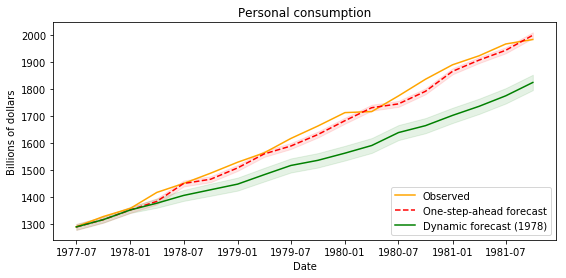

```python
# Graph
fig, ax = plt.subplots(figsize=(9,4))
npre = 4
ax.set(title='Personal consumption', xlabel='Date', ylabel='Billions of dollars')

# Plot data points
ax.plot(data.loc['1977-07-01':, 'consump'], color='orange', label='Observed')

# Plot predictions
ax.plot(predict.predicted_mean.loc['1977-07-01':], ls='--',color='r', label='One-step-ahead forecast')
ci = predict_ci.loc['1977-07-01':]
ax.fill_between(ci.index, ci.iloc[:,0], ci.iloc[:,1], color='red', alpha=0.1)
ax.plot(predict_dy.predicted_mean.loc['1977-07-01':], color='green', label='Dynamic forecast (1978)')
ci = predict_dy_ci.loc['1977-07-01':]
ax.fill_between(ci.index, ci.iloc[:,0], ci.iloc[:,1], color='green', alpha=0.1)
legend = ax.legend(loc='lower right')
plt.show()
```

Finally, graph the prediction error. It is obvious that, as one would suspect, one-step-ahead prediction is considerably better.

[output not shown]

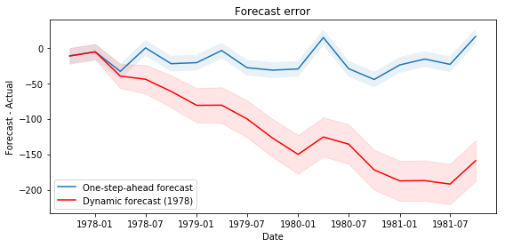

```python
# Prediction error

# Graph
fig, ax = plt.subplots(figsize=(9,4))
npre = 4
ax.set(title='Forecast error', xlabel='Date', ylabel='Forecast - Actual')

# In-sample one-step-ahead predictions and 95% confidence intervals
predict_error = predict.predicted_mean - endog
ax.plot(predict_error.loc['1977-10-01':], label='One-step-ahead forecast')
ci = predict_ci.loc['1977-10-01':].copy()
ci.iloc[:,0] -= endog.loc['1977-10-01':]
ci.iloc[:,1] -= endog.loc['1977-10-01':]
ax.fill_between(ci.index, ci.iloc[:,0], ci.iloc[:,1], alpha=0.1)

# Dynamic predictions and 95% confidence intervals
predict_dy_error = predict_dy.predicted_mean - endog
ax.plot(predict_dy_error.loc['1977-10-01':], color='r', label='Dynamic forecast (1978)')
ci = predict_dy_ci.loc['1977-10-01':].copy()
ci.iloc[:,0] -= endog.loc['1977-10-01':]#这是在减去常数，算error的置信区间
ci.iloc[:,1] -= endog.loc['1977-10-01':]
ax.fill_between(ci.index, ci.iloc[:,0], ci.iloc[:,1], color='r', alpha=0.1)

legend = ax.legend(loc='lower left');
legend.get_frame().set_facecolor('w')
```